# Premier League Data Analysis Project

```python
import pandas as pd
import seaborn as sns
import numpy as np
import matplotlib.pyplot as plt
from sklearn.linear_model import LinearRegression
import warnings
import sklearn as sk
import sklearn.tree as tree
from datetime import date
from sklearn.ensemble import RandomForestClassifier
warnings.filterwarnings('ignore')
from IPython.display import Image
import pydotplus
```

```python
from IPython.core.interactiveshell import InteractiveShell
InteractiveShell.ast_node_interactivity = "all"
```

```python
df = pd.read_csv("matches.csv", index_col=0)
pd.set_option('display.max_columns', 500)
```

### Description of the Dataset

Every row is a match statistics for a particular team.

comp: Competition

round: What week the game is played in

venue: where game is played at for the team column.

result: result of the match {W: Win, D: Draw, L: Loss}

gf: Goals scored for the team

ga: Goals scored against the team

opponent: Opposistion team name

xg: Expected goals scored

xga: Expected goals scored against the team

poss: % of possession a team has during the game

attendance: Amount of people attending the game

captain: Captain of the team during that match for the team column

formation: Team Formation used for the column team during that match

referee: The name of the referee for that match

sh: Shots taken for the team

sot: Shots on target for the team

dist: Average distance, in yards, from goal of all shots taken

fk: Freekicks taken for the team

pk: Penalty kicks made for the team

pkatt: Penalty kicks made for the team

season: Year of season

team: team for the match

```python
df.head()
```

|  | date | time | comp | round | day | venue | result | gf | ga | opponent | xg | xga | poss | attendance | captain | formation | referee | match report | notes | sh | sot | dist | fk | pk | pkatt | season | team |
| --- | --- | --- | --- | --- | --- | --- | --- | --- | --- | --- | --- | --- | --- | --- | --- | --- | --- | --- | --- | --- | --- | --- | --- | --- | --- | --- | --- |
| 1 | 2021-08-15 | 16:30 | Premier League | Matchweek 1 | Sun | Away | L | 0.0 | 1.0 | Tottenham | 1.9 | 1.3 | 64.0 | 58262.0 | Fernandinho | 4-3-3 | Anthony Taylor | Match Report | NaN | 18.0 | 4.0 | 16.9 | 1.0 | 0.0 | 0.0 | 2022 | Manchester City |
| 2 | 2021-08-21 | 15:00 | Premier League | Matchweek 2 | Sat | Home | W | 5.0 | 0.0 | Norwich City | 2.7 | 0.1 | 67.0 | 51437.0 | İlkay Gündoğan | 4-3-3 | Graham Scott | Match Report | NaN | 16.0 | 4.0 | 17.3 | 1.0 | 0.0 | 0.0 | 2022 | Manchester City |
| 3 | 2021-08-28 | 12:30 | Premier League | Matchweek 3 | Sat | Home | W | 5.0 | 0.0 | Arsenal | 3.8 | 0.1 | 80.0 | 52276.0 | İlkay Gündoğan | 4-3-3 | Martin Atkinson | Match Report | NaN | 25.0 | 10.0 | 14.3 | 0.0 | 0.0 | 0.0 | 2022 | Manchester City |
| 4 | 2021-09-11 | 15:00 | Premier League | Matchweek 4 | Sat | Away | W | 1.0 | 0.0 | Leicester City | 2.9 | 0.8 | 61.0 | 32087.0 | İlkay Gündoğan | 4-3-3 | Paul Tierney | Match Report | NaN | 25.0 | 8.0 | 14.0 | 0.0 | 0.0 | 0.0 | 2022 | Manchester City |
| 6 | 2021-09-18 | 15:00 | Premier League | Matchweek 5 | Sat | Home | D | 0.0 | 0.0 | Southampton | 1.1 | 0.4 | 63.0 | 52698.0 | Fernandinho | 4-3-3 | Jonathan Moss | Match Report | NaN | 16.0 | 1.0 | 15.7 | 1.0 | 0.0 | 0.0 | 2022 | Manchester City |

```python
df.shape
```

```
(1389, 27)
```

# Data Cleaning

```python
df.drop(["comp", "notes", 'match report'], axis = 1)
#Dropping comp, notes, match report columns becuase they are irrelevant
```

|  | date | time | round | day | venue | result | gf | ga | opponent | xg | xga | poss | attendance | captain | formation | referee | sh | sot | dist | fk | pk | pkatt | season | team |
| --- | --- | --- | --- | --- | --- | --- | --- | --- | --- | --- | --- | --- | --- | --- | --- | --- | --- | --- | --- | --- | --- | --- | --- | --- |
| 1 | 2021-08-15 | 16:30 | Matchweek 1 | Sun | Away | L | 0.0 | 1.0 | Tottenham | 1.9 | 1.3 | 64.0 | 58262.0 | Fernandinho | 4-3-3 | Anthony Taylor | 18.0 | 4.0 | 16.9 | 1.0 | 0.0 | 0.0 | 2022 | Manchester City |
| 2 | 2021-08-21 | 15:00 | Matchweek 2 | Sat | Home | W | 5.0 | 0.0 | Norwich City | 2.7 | 0.1 | 67.0 | 51437.0 | İlkay Gündoğan | 4-3-3 | Graham Scott | 16.0 | 4.0 | 17.3 | 1.0 | 0.0 | 0.0 | 2022 | Manchester City |
| 3 | 2021-08-28 | 12:30 | Matchweek 3 | Sat | Home | W | 5.0 | 0.0 | Arsenal | 3.8 | 0.1 | 80.0 | 52276.0 | İlkay Gündoğan | 4-3-3 | Martin Atkinson | 25.0 | 10.0 | 14.3 | 0.0 | 0.0 | 0.0 | 2022 | Manchester City |
| 4 | 2021-09-11 | 15:00 | Matchweek 4 | Sat | Away | W | 1.0 | 0.0 | Leicester City | 2.9 | 0.8 | 61.0 | 32087.0 | İlkay Gündoğan | 4-3-3 | Paul Tierney | 25.0 | 8.0 | 14.0 | 0.0 | 0.0 | 0.0 | 2022 | Manchester City |
| 6 | 2021-09-18 | 15:00 | Matchweek 5 | Sat | Home | D | 0.0 | 0.0 | Southampton | 1.1 | 0.4 | 63.0 | 52698.0 | Fernandinho | 4-3-3 | Jonathan Moss | 16.0 | 1.0 | 15.7 | 1.0 | 0.0 | 0.0 | 2022 | Manchester City |
| ... | ... | ... | ... | ... | ... | ... | ... | ... | ... | ... | ... | ... | ... | ... | ... | ... | ... | ... | ... | ... | ... | ... | ... | ... |
| 38 | 2021-05-02 | 19:15 | Matchweek 34 | Sun | Away | L | 0.0 | 4.0 | Tottenham | 0.5 | 2.0 | 34.0 | NaN | John Egan | 3-4-1-2 | Andre Marriner | 8.0 | 1.0 | 17.4 | 0.0 | 0.0 | 0.0 | 2021 | Sheffield United |
| 39 | 2021-05-08 | 15:00 | Matchweek 35 | Sat | Home | L | 0.0 | 2.0 | Crystal Palace | 0.7 | 2.1 | 50.0 | NaN | John Egan | 3-5-2 | Simon Hooper | 7.0 | 0.0 | 11.4 | 1.0 | 0.0 | 0.0 | 2021 | Sheffield United |
| 40 | 2021-05-16 | 19:00 | Matchweek 36 | Sun | Away | W | 1.0 | 0.0 | Everton | 1.6 | 1.3 | 38.0 | NaN | John Egan | 3-4-3 | Jonathan Moss | 10.0 | 3.0 | 17.0 | 0.0 | 0.0 | 0.0 | 2021 | Sheffield United |
| 41 | 2021-05-19 | 18:00 | Matchweek 37 | Wed | Away | L | 0.0 | 1.0 | Newcastle Utd | 0.8 | 1.5 | 50.0 | 10000.0 | John Egan | 3-4-3 | Robert Jones | 11.0 | 1.0 | 16.0 | 1.0 | 0.0 | 0.0 | 2021 | Sheffield United |
| 42 | 2021-05-23 | 16:00 | Matchweek 38 | Sun | Home | W | 1.0 | 0.0 | Burnley | 0.6 | 1.0 | 41.0 | 5000.0 | John Egan | 3-4-3 | Kevin Friend | 12.0 | 3.0 | 17.0 | 0.0 | 0.0 | 0.0 | 2021 | Sheffield United |

1389 rows × 24 columns

```python
df['date'] = pd.to_datetime(df['date'])
df['hour'] = df['time'].str.replace(':.+', '', regex = True).astype('int')
df['dayNum'] = df['date'].dt.dayofweek
#Turns date into numerical hours and days
```

```python
df['venueNum'] = df['venue'].astype('category').cat.codes
#Turns Home and Away into binary numbers
```

```python
def Weekend(dayNum):
    if dayNum == 6:
        return 1
    elif dayNum == 5:
        return 1
    else:
        return 0
df['Weekend?'] = df['dayNum'].apply(Weekend)
#Decides if the day is a weekend or not
```

```python
def resultnum(result):
    if result == 'W':
        return 1
    elif result == 'D':
        return 0.5
    else:
        return 0
df['Result Number'] = df['result'].apply(resultnum)
#Turns W,D,L into numerical numbers
```

```python
def top6(opponent):
    if opponent == 'Arsenal':
        return 1
    elif opponent == 'Chelsea':
        return 1
    elif opponent == 'Tottenham':
        return 1
    elif opponent == 'Manchester City':
        return 1
    elif opponent == 'Manchester United':
        return 1
    elif opponent == 'Liverpool':
        return 1
    else:
        return 0
df['Top_6_Teams_Opp'] = df['opponent'].apply(top6)
# 1 is if opponent is considered a top 6 team
```

```python
def top6(opponent):
    if opponent == 'Arsenal':
        return 1
    elif opponent == 'Chelsea':
        return 1
    elif opponent == 'Tottenham Hotspur':
        return 1
    elif opponent == 'Manchester City':
        return 1
    elif opponent == 'Manchester United':
        return 1
    elif opponent == 'Liverpool':
        return 1
    else:
        return 0
df['Top_6_Teams'] = df['team'].apply(top6)
# 1 is if team is considered a top 6 team
```

```python
df['Month'] = pd.DatetimeIndex(df['date']).month
df['Year'] = pd.DatetimeIndex(df['date']).year
def winter(Month):
    if Month > 10:
        return 1
    elif Month < 3:
        return 1
    else:
        return 0
df['Winter?'] = df['Month'].apply(winter)

#created a winter vs non winter column. if month is november to febuary, then it is a winter month
```

```python
df['Total Goals'] = df['gf'] +df['ga']
#added up total goals in a column
```

```python
def Zero(Goals):
    if Goals == 0:
        return 1
    else:
        return 0
df['Zero Goal Game'] = df['Total Goals'].apply(Zero)
#1 if there is no goals in the game
```

```python
def Zeroone(Goals):
    if Goals <= 1:
        return 1
    else:
        return 0
df['Low Scoring Game'] = df['Total Goals'].apply(Zeroone)
#1 if there is 1 or less goals in the game
```

```python
df
```

|  | date | time | comp | round | day | venue | result | gf | ga | opponent | xg | xga | poss | attendance | captain | formation | referee | match report | notes | sh | sot | dist | fk | pk | pkatt | season | team | hour | dayNum | … |
| --- | --- | --- | --- | --- | --- | --- | --- | --- | --- | --- | --- | --- | --- | --- | --- | --- | --- | --- | --- | --- | --- | --- | --- | --- | --- | --- | --- | --- | --- | --- |
| 1 | 2021-08-15 | 16:30 | Premier League | Matchweek 1 | Sun | Away | L | 0.0 | 1.0 | Tottenham | 1.9 | 1.3 | 64.0 | 58262.0 | Fernandinho | 4-3-3 | Anthony Taylor | Match Report | NaN | 18.0 | 4.0 | 16.9 | 1.0 | 0.0 | 0.0 | 2022 | Manchester City | 16 | 6 | … |
| 2 | 2021-08-21 | 15:00 | Premier League | Matchweek 2 | Sat | Home | W | 5.0 | 0.0 | Norwich City | 2.7 | 0.1 | 67.0 | 51437.0 | İlkay Gündoğan | 4-3-3 | Graham Scott | Match Report | NaN | 16.0 | 4.0 | 17.3 | 1.0 | 0.0 | 0.0 | 2022 | Manchester City | 15 | 5 | … |
| 3 | 2021-08-28 | 12:30 | Premier League | Matchweek 3 | Sat | Home | W | 5.0 | 0.0 | Arsenal | 3.8 | 0.1 | 80.0 | 52276.0 | İlkay Gündoğan | 4-3-3 | Martin Atkinson | Match Report | NaN | 25.0 | 10.0 | 14.3 | 0.0 | 0.0 | 0.0 | 2022 | Manchester City | 12 | 5 | … |
| 4 | 2021-09-11 | 15:00 | Premier League | Matchweek 4 | Sat | Away | W | 1.0 | 0.0 | Leicester City | 2.9 | 0.8 | 61.0 | 32087.0 | İlkay Gündoğan | 4-3-3 | Paul Tierney | Match Report | NaN | 25.0 | 8.0 | 14.0 | 0.0 | 0.0 | 0.0 | 2022 | Manchester City | 15 | 5 | … |
| 6 | 2021-09-18 | 15:00 | Premier League | Matchweek 5 | Sat | Home | D | 0.0 | 0.0 | Southampton | 1.1 | 0.4 | 63.0 | 52698.0 | Fernandinho | 4-3-3 | Jonathan Moss | Match Report | NaN | 16.0 | 1.0 | 15.7 | 1.0 | 0.0 | 0.0 | 2022 | Manchester City | 15 | 5 | … |
| ... | ... | ... | ... | ... | ... | ... | ... | ... | ... | ... | ... | ... | ... | ... | ... | ... | ... | ... | ... | ... | ... | ... | ... | ... | ... | ... | ... | ... | ... | … |
| 38 | 2021-05-02 | 19:15 | Premier League | Matchweek 34 | Sun | Away | L | 0.0 | 4.0 | Tottenham | 0.5 | 2.0 | 34.0 | NaN | John Egan | 3-4-1-2 | Andre Marriner | Match Report | NaN | 8.0 | 1.0 | 17.4 | 0.0 | 0.0 | 0.0 | 2021 | Sheffield United | 19 | 6 | … |
| 39 | 2021-05-08 | 15:00 | Premier League | Matchweek 35 | Sat | Home | L | 0.0 | 2.0 | Crystal Palace | 0.7 | 2.1 | 50.0 | NaN | John Egan | 3-5-2 | Simon Hooper | Match Report | NaN | 7.0 | 0.0 | 11.4 | 1.0 | 0.0 | 0.0 | 2021 | Sheffield United | 15 | 5 | … |
| 40 | 2021-05-16 | 19:00 | Premier League | Matchweek 36 | Sun | Away | W | 1.0 | 0.0 | Everton | 1.6 | 1.3 | 38.0 | NaN | John Egan | 3-4-3 | Jonathan Moss | Match Report | NaN | 10.0 | 3.0 | 17.0 | 0.0 | 0.0 | 0.0 | 2021 | Sheffield United | 19 | 6 | … |
| 41 | 2021-05-19 | 18:00 | Premier League | Matchweek 37 | Wed | Away | L | 0.0 | 1.0 | Newcastle Utd | 0.8 | 1.5 | 50.0 | 10000.0 | John Egan | 3-4-3 | Robert Jones | Match Report | NaN | 11.0 | 1.0 | 16.0 | 1.0 | 0.0 | 0.0 | 2021 | Sheffield United | 18 | 2 | … |
| 42 | 2021-05-23 | 16:00 | Premier League | Matchweek 38 | Sun | Home | W | 1.0 | 0.0 | Burnley | 0.6 | 1.0 | 41.0 | 5000.0 | John Egan | 3-4-3 | Kevin Friend | Match Report | NaN | 12.0 | 3.0 | 17.0 | 0.0 | 0.0 | 0.0 | 2021 | Sheffield United | 16 | 6 | … |

1389 rows × 40 columns

```python
#Create a DF with only top 6 teams
Top_6 = df[df['Top_6_Teams']== 1]
Top_6.head(60)
```

|  | date | time | comp | round | day | venue | result | gf | ga | opponent | xg | xga | poss | attendance | captain | formation | referee | match report | notes | sh | sot | dist | fk | pk | pkatt | season | team | hour | dayNum | … |
| --- | --- | --- | --- | --- | --- | --- | --- | --- | --- | --- | --- | --- | --- | --- | --- | --- | --- | --- | --- | --- | --- | --- | --- | --- | --- | --- | --- | --- | --- | --- |
| 1 | 2021-08-15 | 16:30 | Premier League | Matchweek 1 | Sun | Away | L | 0.0 | 1.0 | Tottenham | 1.9 | 1.3 | 64.0 | 58262.0 | Fernandinho | 4-3-3 | Anthony Taylor | Match Report | NaN | 18.0 | 4.0 | 16.9 | 1.0 | 0.0 | 0.0 | 2022 | Manchester City | 16 | 6 | … |
| 2 | 2021-08-21 | 15:00 | Premier League | Matchweek 2 | Sat | Home | W | 5.0 | 0.0 | Norwich City | 2.7 | 0.1 | 67.0 | 51437.0 | İlkay Gündoğan | 4-3-3 | Graham Scott | Match Report | NaN | 16.0 | 4.0 | 17.3 | 1.0 | 0.0 | 0.0 | 2022 | Manchester City | 15 | 5 | … |
| 3 | 2021-08-28 | 12:30 | Premier League | Matchweek 3 | Sat | Home | W | 5.0 | 0.0 | Arsenal | 3.8 | 0.1 | 80.0 | 52276.0 | İlkay Gündoğan | 4-3-3 | Martin Atkinson | Match Report | NaN | 25.0 | 10.0 | 14.3 | 0.0 | 0.0 | 0.0 | 2022 | Manchester City | 12 | 5 | … |
| 4 | 2021-09-11 | 15:00 | Premier League | Matchweek 4 | Sat | Away | W | 1.0 | 0.0 | Leicester City | 2.9 | 0.8 | 61.0 | 32087.0 | İlkay Gündoğan | 4-3-3 | Paul Tierney | Match Report | NaN | 25.0 | 8.0 | 14.0 | 0.0 | 0.0 | 0.0 | 2022 | Manchester City | 15 | 5 | … |
| 6 | 2021-09-18 | 15:00 | Premier League | Matchweek 5 | Sat | Home | D | 0.0 | 0.0 | Southampton | 1.1 | 0.4 | 63.0 | 52698.0 | Fernandinho | 4-3-3 | Jonathan Moss | Match Report | NaN | 16.0 | 1.0 | 15.7 | 1.0 | 0.0 | 0.0 | 2022 | Manchester City | 15 | 5 | … |
| 8 | 2021-09-25 | 12:30 | Premier League | Matchweek 6 | Sat | Away | W | 1.0 | 0.0 | Chelsea | 1.7 | 0.3 | 60.0 | 40036.0 | Rúben Dias | 4-3-3 | Michael Oliver | Match Report | NaN | 15.0 | 3.0 | 16.5 | 0.0 | 0.0 | 0.0 | 2022 | Manchester City | 12 | 5 | … |
| 10 | 2021-10-03 | 16:30 | Premier League | Matchweek 7 | Sun | Away | D | 2.0 | 2.0 | Liverpool | 1.2 | 1.0 | 51.0 | 53102.0 | Rúben Dias | 4-3-3 | Paul Tierney | Match Report | NaN | 12.0 | 3.0 | 16.8 | 1.0 | 0.0 | 0.0 | 2022 | Manchester City | 16 | 6 | … |
| 11 | 2021-10-16 | 15:00 | Premier League | Matchweek 8 | Sat | Home | W | 2.0 | 0.0 | Burnley | 1.9 | 1.0 | 69.0 | 52711.0 | Kevin De Bruyne | 4-3-3 | Martin Atkinson | Match Report | NaN | 16.0 | 6.0 | 14.6 | 0.0 | 0.0 | 0.0 | 2022 | Manchester City | 15 | 5 | … |
| 13 | 2021-10-23 | 17:30 | Premier League | Matchweek 9 | Sat | Away | W | 4.0 | 1.0 | Brighton | 3.9 | 1.3 | 52.0 | 31215.0 | İlkay Gündoğan | 4-3-3 | Kevin Friend | Match Report | NaN | 23.0 | 13.0 | 15.7 | 1.0 | 0.0 | 0.0 | 2022 | Manchester City | 17 | 5 | … |
| 15 | 2021-10-30 | 15:00 | Premier League | Matchweek 10 | Sat | Home | L | 0.0 | 2.0 | Crystal Palace | 1.1 | 1.1 | 68.0 | 53014.0 | Rúben Dias | 4-3-3 | Andre Marriner | Match Report | NaN | 14.0 | 3.0 | 17.0 | 0.0 | 0.0 | 0.0 | 2022 | Manchester City | 15 | 5 | … |
| 17 | 2021-11-06 | 12:30 | Premier League | Matchweek 11 | Sat | Away | W | 2.0 | 0.0 | Manchester Utd | 2.0 | 0.6 | 67.0 | 73086.0 | İlkay Gündoğan | 4-3-3 | Michael Oliver | Match Report | NaN | 16.0 | 5.0 | 14.6 | 0.0 | 0.0 | 0.0 | 2022 | Manchester City | 12 | 5 | … |
| 18 | 2021-11-21 | 14:00 | Premier League | Matchweek 12 | Sun | Home | W | 3.0 | 0.0 | Everton | 2.3 | 0.3 | 76.0 | 52571.0 | İlkay Gündoğan | 4-3-3 | Stuart Attwell | Match Report | NaN | 17.0 | 7.0 | 15.4 | 1.0 | 0.0 | 0.0 | 2022 | Manchester City | 14 | 6 | … |
| 20 | 2021-11-28 | 14:00 | Premier League | Matchweek 13 | Sun | Home | W | 2.0 | 1.0 | West Ham | 2.1 | 0.2 | 67.0 | 53245.0 | İlkay Gündoğan | 4-3-3 | Michael Oliver | Match Report | NaN | 19.0 | 8.0 | 14.8 | 0.0 | 0.0 | 0.0 | 2022 | Manchester City | 14 | 6 | … |
| 21 | 2021-12-01 | 20:15 | Premier League | Matchweek 14 | Wed | Away | W | 2.0 | 1.0 | Aston Villa | 0.9 | 0.9 | 64.0 | 41400.0 | Fernandinho | 4-2-3-1 | Mike Dean | Match Report | NaN | 17.0 | 7.0 | 19.0 | 1.0 | 0.0 | 0.0 | 2022 | Manchester City | 20 | 2 | … |
| 22 | 2021-12-04 | 17:30 | Premier League | Matchweek 15 | Sat | Away | W | 3.0 | 1.0 | Watford | 3.6 | 0.7 | 76.0 | 20673.0 | İlkay Gündoğan | 4-3-3 | Simon Hooper | Match Report | NaN | 26.0 | 12.0 | 14.0 | 0.0 | 0.0 | 0.0 | 2022 | Manchester City | 17 | 5 | … |
| 24 | 2021-12-11 | 12:30 | Premier League | Matchweek 16 | Sat | Home | W | 1.0 | 0.0 | Wolves | 3.5 | 0.2 | 71.0 | 52613.0 | İlkay Gündoğan | 4-3-3 | Jonathan Moss | Match Report | NaN | 23.0 | 8.0 | 15.2 | 0.0 | 1.0 | 1.0 | 2022 | Manchester City | 12 | 5 | … |
| 25 | 2021-12-14 | 20:00 | Premier League | Matchweek 17 | Tue | Home | W | 7.0 | 0.0 | Leeds United | 3.6 | 0.2 | 64.0 | 52401.0 | Rúben Dias | 4-3-3 | Paul Tierney | Match Report | NaN | 31.0 | 15.0 | 16.2 | 2.0 | 0.0 | 0.0 | 2022 | Manchester City | 20 | 1 | … |
| 26 | 2021-12-19 | 14:15 | Premier League | Matchweek 18 | Sun | Away | W | 4.0 | 0.0 | Newcastle Utd | 3.1 | 0.4 | 71.0 | 52127.0 | Rúben Dias | 4-3-3 | Martin Atkinson | Match Report | NaN | 18.0 | 7.0 | 11.8 | 0.0 | 0.0 | 0.0 | 2022 | Manchester City | 14 | 6 | … |
| 27 | 2021-12-26 | 15:00 | Premier League | Matchweek 19 | Sun | Home | W | 6.0 | 3.0 | Leicester City | 3.4 | 2.4 | 72.0 | 53226.0 | Fernandinho | 4-3-3 | Chris Kavanagh | Match Report | NaN | 15.0 | 6.0 | 16.6 | 1.0 | 2.0 | 2.0 | 2022 | Manchester City | 15 | 6 | … |
| 28 | 2021-12-29 | 20:15 | Premier League | Matchweek 20 | Wed | Away | W | 1.0 | 0.0 | Brentford | 0.8 | 0.3 | 76.0 | 17009.0 | Fernandinho | 4-3-3 | David Coote | Match Report | NaN | 12.0 | 4.0 | 18.7 | 0.0 | 0.0 | 0.0 | 2022 | Manchester City | 20 | 2 | … |
| 29 | 2022-01-01 | 12:30 | Premier League | Matchweek 21 | Sat | Away | W | 2.0 | 1.0 | Arsenal | 1.8 | 1.0 | 70.0 | 59757.0 | Rúben Dias | 4-3-3 | Stuart Attwell | Match Report | NaN | 14.0 | 1.0 | 18.4 | 0.0 | 1.0 | 1.0 | 2022 | Manchester City | 12 | 5 | … |
| 31 | 2022-01-15 | 12:30 | Premier League | Matchweek 22 | Sat | Home | W | 1.0 | 0.0 | Chelsea | 0.7 | 0.5 | 56.0 | 53319.0 | Kevin De Bruyne | 4-3-3 | Craig Pawson | Match Report | NaN | 11.0 | 6.0 | 16.7 | 1.0 | 0.0 | 0.0 | 2022 | Manchester City | 12 | 5 | … |
| 32 | 2022-01-22 | 17:30 | Premier League | Matchweek 23 | Sat | Away | D | 1.0 | 1.0 | Southampton | 1.6 | 1.1 | 73.0 | 31178.0 | Rúben Dias | 4-3-3 | Simon Hooper | Match Report | NaN | 20.0 | 5.0 | 16.5 | 0.0 | 0.0 | 0.0 | 2022 | Manchester City | 17 | 5 | … |
| 34 | 2022-02-09 | 19:45 | Premier League | Matchweek 24 | Wed | Home | W | 2.0 | 0.0 | Brentford | 2.0 | 0.7 | 75.0 | 51658.0 | Rúben Dias | 4-3-3 | Darren England | Match Report | NaN | 14.0 | 6.0 | 18.8 | 0.0 | 1.0 | 1.0 | 2022 | Manchester City | 19 | 2 | … |
| 35 | 2022-02-12 | 17:30 | Premier League | Matchweek 25 | Sat | Away | W | 4.0 | 0.0 | Norwich City | 4.6 | 0.5 | 72.0 | 27010.0 | Fernandinho | 4-3-3 | Andre Marriner | Match Report | NaN | 21.0 | 8.0 | 11.6 | 0.0 | 0.0 | 1.0 | 2022 | Manchester City | 17 | 5 | … |
| 37 | 2022-02-19 | 17:30 | Premier League | Matchweek 26 | Sat | Home | L | 2.0 | 3.0 | Tottenham | 2.1 | 1.8 | 71.0 | 53201.0 | İlkay Gündoğan | 4-3-3 | Anthony Taylor | Match Report | NaN | 20.0 | 3.0 | 15.6 | 0.0 | 1.0 | 1.0 | 2022 | Manchester City | 17 | 5 | … |
| 38 | 2022-02-26 | 17:30 | Premier League | Matchweek 27 | Sat | Away | W | 1.0 | 0.0 | Everton | 1.6 | 0.8 | 67.0 | 39105.0 | İlkay Gündoğan | 4-3-3 | Paul Tierney | Match Report | NaN | 13.0 | 8.0 | 15.7 | 0.0 | 0.0 | 0.0 | 2022 | Manchester City | 17 | 5 | … |
| 40 | 2022-03-06 | 16:30 | Premier League | Matchweek 28 | Sun | Home | W | 4.0 | 1.0 | Manchester Utd | 2.6 | 0.5 | 69.0 | 53165.0 | Kevin De Bruyne | 4-3-3 | Michael Oliver | Match Report | NaN | 24.0 | 10.0 | 14.8 | 1.0 | 0.0 | 0.0 | 2022 | Manchester City | 16 | 6 | … |
| 42 | 2022-03-14 | 20:00 | Premier League | Matchweek 29 | Mon | Away | D | 0.0 | 0.0 | Crystal Palace | 2.3 | 0.8 | 74.0 | 25309.0 | Kevin De Bruyne | 4-3-3 | Martin Atkinson | Match Report | NaN | 18.0 | 4.0 | 17.5 | 0.0 | 0.0 | 0.0 | 2022 | Manchester City | 20 | 0 | … |
| 44 | 2022-04-02 | 15:00 | Premier League | Matchweek 31 | Sat | Away | W | 2.0 | 0.0 | Burnley | 1.8 | 0.1 | 75.0 | 21249.0 | İlkay Gündoğan | 4-3-3 | Craig Pawson | Match Report | NaN | 18.0 | 6.0 | 16.1 | 0.0 | 0.0 | 0.0 | 2022 | Manchester City | 15 | 5 | … |
| 46 | 2022-04-10 | 16:30 | Premier League | Matchweek 32 | Sun | Home | D | 2.0 | 2.0 | Liverpool | 2.0 | 1.0 | 55.0 | 53197.0 | Kevin De Bruyne | 4-2-3-1 | Anthony Taylor | Match Report | NaN | 11.0 | 4.0 | 16.5 | 1.0 | 0.0 | 0.0 | 2022 | Manchester City | 16 | 6 | … |
| 49 | 2022-04-20 | 20:00 | Premier League | Matchweek 30 | Wed | Home | W | 3.0 | 0.0 | Brighton | 1.2 | 0.1 | 64.0 | 52226.0 | İlkay Gündoğan | 4-3-3 | Mike Dean | Match Report | NaN | 17.0 | 5.0 | 19.0 | 0.0 | 0.0 | 0.0 | 2022 | Manchester City | 20 | 2 | … |
| 50 | 2022-04-23 | 15:00 | Premier League | Matchweek 34 | Sat | Home | W | 5.0 | 1.0 | Watford | 3.0 | 0.5 | 73.0 | 53013.0 | Fernandinho | 4-2-3-1 | Kevin Friend | Match Report | NaN | 20.0 | 7.0 | 14.7 | 0.0 | 1.0 | 1.0 | 2022 | Manchester City | 15 | 5 | … |
| 1 | 2021-08-14 | 15:00 | Premier League | Matchweek 1 | Sat | Home | W | 3.0 | 0.0 | Crystal Palace | 0.9 | 0.3 | 62.0 | 38965.0 | César Azpilicueta | 3-4-3 | Jonathan Moss | Match Report | NaN | 13.0 | 6.0 | 20.8 | 4.0 | 0.0 | 0.0 | 2022 | Chelsea | 15 | 5 | … |
| 2 | 2021-08-22 | 16:30 | Premier League | Matchweek 2 | Sun | Away | W | 2.0 | 0.0 | Arsenal | 2.9 | 0.3 | 65.0 | 58729.0 | César Azpilicueta | 3-4-3 | Paul Tierney | Match Report | NaN | 22.0 | 5.0 | 14.6 | 0.0 | 0.0 | 0.0 | 2022 | Chelsea | 16 | 6 | … |
| 3 | 2021-08-28 | 17:30 | Premier League | Matchweek 3 | Sat | Away | D | 1.0 | 1.0 | Liverpool | 0.8 | 2.6 | 35.0 | 54000.0 | César Azpilicueta | 3-4-3 | Anthony Taylor | Match Report | NaN | 6.0 | 2.0 | 12.3 | 0.0 | 0.0 | 0.0 | 2022 | Chelsea | 17 | 5 | … |
| 4 | 2021-09-11 | 17:30 | Premier League | Matchweek 4 | Sat | Home | W | 3.0 | 0.0 | Aston Villa | 1.1 | 1.5 | 57.0 | 39969.0 | Marcos Alonso | 3-4-3 | Stuart Attwell | Match Report | NaN | 12.0 | 4.0 | 22.5 | 0.0 | 0.0 | 0.0 | 2022 | Chelsea | 17 | 5 | … |
| 6 | 2021-09-19 | 16:30 | Premier League | Matchweek 5 | Sun | Away | W | 3.0 | 0.0 | Tottenham | 1.9 | 0.7 | 53.0 | 60059.0 | César Azpilicueta | 3-4-3 | Paul Tierney | Match Report | NaN | 20.0 | 9.0 | 13.2 | 0.0 | 0.0 | 0.0 | 2022 | Chelsea | 16 | 6 | … |
| 8 | 2021-09-25 | 12:30 | Premier League | Matchweek 6 | Sat | Home | L | 0.0 | 1.0 | Manchester City | 0.3 | 1.7 | 40.0 | 40036.0 | César Azpilicueta | 3-5-2 | Michael Oliver | Match Report | NaN | 5.0 | 0.0 | 29.3 | 1.0 | 0.0 | 0.0 | 2022 | Chelsea | 12 | 5 | … |
| 10 | 2021-10-02 | 15:00 | Premier League | Matchweek 7 | Sat | Home | W | 3.0 | 1.0 | Southampton | 3.6 | 1.3 | 62.0 | 40109.0 | César Azpilicueta | 3-4-3 | Martin Atkinson | Match Report | NaN | 20.0 | 9.0 | 13.2 | 0.0 | 0.0 | 0.0 | 2022 | Chelsea | 15 | 5 | … |
| 11 | 2021-10-16 | 17:30 | Premier League | Matchweek 8 | Sat | Away | W | 1.0 | 0.0 | Brentford | 0.3 | 1.6 | 56.0 | 16940.0 | César Azpilicueta | 3-5-2 | Anthony Taylor | Match Report | NaN | 5.0 | 1.0 | 23.3 | 2.0 | 0.0 | 0.0 | 2022 | Chelsea | 17 | 5 | … |
| 13 | 2021-10-23 | 12:30 | Premier League | Matchweek 9 | Sat | Home | W | 7.0 | 0.0 | Norwich City | 3.2 | 0.2 | 63.0 | 40113.0 | Jorginho | 3-4-3 | Andy Madley | Match Report | NaN | 22.0 | 12.0 | 19.8 | 0.0 | 1.0 | 1.0 | 2022 | Chelsea | 12 | 5 | … |
| 15 | 2021-10-30 | 15:00 | Premier League | Matchweek 10 | Sat | Away | W | 3.0 | 0.0 | Newcastle Utd | 2.1 | 0.3 | 77.0 | 52208.0 | Jorginho | 3-4-3 | Paul Tierney | Match Report | NaN | 18.0 | 5.0 | 19.8 | 1.0 | 1.0 | 1.0 | 2022 | Chelsea | 15 | 5 | … |
| 17 | 2021-11-06 | 15:00 | Premier League | Matchweek 11 | Sat | Home | D | 1.0 | 1.0 | Burnley | 2.2 | 1.0 | 68.0 | 39798.0 | Jorginho | 3-4-1-2 | Andre Marriner | Match Report | NaN | 25.0 | 4.0 | 14.9 | 0.0 | 0.0 | 0.0 | 2022 | Chelsea | 15 | 5 | … |
| 18 | 2021-11-20 | 12:30 | Premier League | Matchweek 12 | Sat | Away | W | 3.0 | 0.0 | Leicester City | 2.4 | 0.4 | 61.0 | 35497.0 | Jorginho | 3-4-3 | Paul Tierney | Match Report | NaN | 16.0 | 7.0 | 15.7 | 2.0 | 0.0 | 0.0 | 2022 | Chelsea | 12 | 5 | … |
| 20 | 2021-11-28 | 16:30 | Premier League | Matchweek 13 | Sun | Home | D | 1.0 | 1.0 | Manchester Utd | 2.9 | 0.7 | 65.0 | 40041.0 | Jorginho | 3-4-3 | Anthony Taylor | Match Report | NaN | 23.0 | 5.0 | 16.0 | 0.0 | 1.0 | 1.0 | 2022 | Chelsea | 16 | 6 | … |
| 21 | 2021-12-01 | 19:30 | Premier League | Matchweek 14 | Wed | Away | W | 2.0 | 1.0 | Watford | 1.3 | 1.0 | 49.0 | 20388.0 | César Azpilicueta | 3-4-3 | David Coote | Match Report | NaN | 8.0 | 4.0 | 14.4 | 0.0 | 0.0 | 0.0 | 2022 | Chelsea | 19 | 2 | … |
| 22 | 2021-12-04 | 12:30 | Premier League | Matchweek 15 | Sat | Away | L | 2.0 | 3.0 | West Ham | 1.2 | 1.8 | 63.0 | 59942.0 | Jorginho | 3-4-3 | Andre Marriner | Match Report | NaN | 19.0 | 7.0 | 16.8 | 0.0 | 0.0 | 0.0 | 2022 | Chelsea | 12 | 5 | … |
| 24 | 2021-12-11 | 15:00 | Premier League | Matchweek 16 | Sat | Home | W | 3.0 | 2.0 | Leeds United | 2.8 | 1.4 | 57.0 | 39959.0 | César Azpilicueta | 3-4-3 | Chris Kavanagh | Match Report | NaN | 14.0 | 4.0 | 20.5 | 2.0 | 2.0 | 2.0 | 2022 | Chelsea | 15 | 5 | … |
| 25 | 2021-12-16 | 19:45 | Premier League | Matchweek 17 | Thu | Home | D | 1.0 | 1.0 | Everton | 2.7 | 0.4 | 79.0 | 13933.0 | César Azpilicueta | 3-4-3 | Michael Oliver | Match Report | NaN | 23.0 | 10.0 | 14.8 | 2.0 | 0.0 | 0.0 | 2022 | Chelsea | 19 | 3 | … |
| 26 | 2021-12-19 | 14:00 | Premier League | Matchweek 18 | Sun | Away | D | 0.0 | 0.0 | Wolves | 0.8 | 0.3 | 63.0 | 30631.0 | César Azpilicueta | 3-4-3 | David Coote | Match Report | NaN | 8.0 | 1.0 | 14.9 | 0.0 | 0.0 | 0.0 | 2022 | Chelsea | 14 | 6 | … |
| 28 | 2021-12-26 | 17:30 | Premier League | Matchweek 19 | Sun | Away | W | 3.0 | 1.0 | Aston Villa | 2.8 | 0.6 | 58.0 | 41907.0 | Jorginho | 3-4-3 | Martin Atkinson | Match Report | NaN | 8.0 | 2.0 | 17.3 | 1.0 | 2.0 | 2.0 | 2022 | Chelsea | 17 | 6 | … |
| 29 | 2021-12-29 | 19:30 | Premier League | Matchweek 20 | Wed | Home | D | 1.0 | 1.0 | Brighton | 1.1 | 0.9 | 49.0 | 40080.0 | César Azpilicueta | 3-4-3 | Mike Dean | Match Report | NaN | 11.0 | 5.0 | 12.7 | 0.0 | 0.0 | 0.0 | 2022 | Chelsea | 19 | 2 | … |
| 30 | 2022-01-02 | 16:30 | Premier League | Matchweek 21 | Sun | Home | D | 2.0 | 2.0 | Liverpool | 1.3 | 1.4 | 55.0 | 40072.0 | César Azpilicueta | 3-4-3 | Anthony Taylor | Match Report | NaN | 15.0 | 6.0 | 17.2 | 3.0 | 0.0 | 0.0 | 2022 | Chelsea | 16 | 6 | … |
| 34 | 2022-01-15 | 12:30 | Premier League | Matchweek 22 | Sat | Away | L | 0.0 | 1.0 | Manchester City | 0.5 | 0.7 | 44.0 | 53319.0 | César Azpilicueta | 3-4-3 | Craig Pawson | Match Report | NaN | 4.0 | 1.0 | 18.8 | 0.0 | 0.0 | 0.0 | 2022 | Chelsea | 12 | 5 | … |
| 35 | 2022-01-18 | 20:00 | Premier League | Matchweek 24 | Tue | Away | D | 1.0 | 1.0 | Brighton | 0.7 | 0.6 | 56.0 | 30880.0 | César Azpilicueta | 4-2-2-2 | Kevin Friend | Match Report | NaN | 15.0 | 3.0 | 20.3 | 1.0 | 0.0 | 0.0 | 2022 | Chelsea | 20 | 1 | … |
| 36 | 2022-01-23 | 16:30 | Premier League | Matchweek 23 | Sun | Home | W | 2.0 | 0.0 | Tottenham | 0.9 | 0.4 | 65.0 | 40020.0 | César Azpilicueta | 4-3-3 | Paul Tierney | Match Report | NaN | 15.0 | 7.0 | 15.0 | 0.0 | 0.0 | 0.0 | 2022 | Chelsea | 16 | 6 | … |
| 38 | 2022-02-19 | 15:00 | Premier League | Matchweek 26 | Sat | Away | W | 1.0 | 0.0 | Crystal Palace | 1.1 | 0.6 | 58.0 | 25109.0 | Jorginho | 4-3-3 | David Coote | Match Report | NaN | 10.0 | 3.0 | 17.5 | 1.0 | 0.0 | 0.0 | 2022 | Chelsea | 15 | 5 | … |
| 42 | 2022-03-05 | 15:00 | Premier League | Matchweek 28 | Sat | Away | W | 4.0 | 0.0 | Burnley | 2.2 | 0.8 | 72.0 | 19439.0 | Jorginho | 3-4-3 | Andre Marriner | Match Report | NaN | 11.0 | 5.0 | 16.9 | 0.0 | 0.0 | 0.0 | 2022 | Chelsea | 15 | 5 | … |
| 43 | 2022-03-10 | 19:30 | Premier League | Matchweek 30 | Thu | Away | W | 3.0 | 1.0 | Norwich City | 1.9 | 1.0 | 66.0 | 26684.0 | César Azpilicueta | 3-4-3 | Martin Atkinson | Match Report | NaN | 15.0 | 7.0 | 12.4 | 1.0 | 0.0 | 0.0 | 2022 | Chelsea | 19 | 3 | … |

# Insight 1: Does Venue Matter?

```python
GBmean = df.groupby(['team', 'venue']).mean()
GBmean.rename({'Result Number': 'Average Winning %'}, axis=1, inplace = True)
GBmean.reset_index(inplace = True)
```

```python
GBmean
```

|  | team | venue | gf | ga | xg | xga | poss | attendance | notes | sh | sot | dist | fk | pk | pkatt | season | hour | dayNum | venueNum | Weekend? | Average Winning % | Top_6_Teams_Opp | Top_6_Teams | Month | Year | Winter? | Total Goals | Zero Goal Game | Low Scoring Game |
| --- | --- | --- | --- | --- | --- | --- | --- | --- | --- | --- | --- | --- | --- | --- | --- | --- | --- | --- | --- | --- | --- | --- | --- | --- | --- | --- | --- | --- | --- |
| 0 | Arsenal | Away | 1.571429 | 1.228571 | 1.462857 | 1.308571 | 51.571429 | 31802.277778 | NaN | 12.171429 | 3.800000 | 16.880000 | 0.514286 | 0.142857 | 0.142857 | 2021.457143 | 16.485714 | 4.085714 | 0.0 | 0.657143 | 0.571429 | 0.200000 | 1.0 | 6.942857 | 2020.942857 | 0.457143 | 2.800000 | 0.057143 | 0.314286 |
| 1 | Arsenal | Home | 1.444444 | 1.000000 | 1.511111 | 1.063889 | 54.611111 | 53964.789474 | NaN | 14.805556 | 4.527778 | 17.291667 | 0.666667 | 0.138889 | 0.222222 | 2021.472222 | 16.916667 | 4.750000 | 1.0 | 0.750000 | 0.611111 | 0.222222 | 1.0 | 6.416667 | 2021.000000 | 0.500000 | 2.444444 | 0.083333 | 0.250000 |
| 2 | Aston Villa | Away | 1.222222 | 1.111111 | 1.194444 | 1.247222 | 47.333333 | 38285.500000 | NaN | 12.583333 | 4.250000 | 17.475000 | 0.666667 | 0.111111 | 0.138889 | 2021.472222 | 16.777778 | 4.194444 | 0.0 | 0.638889 | 0.472222 | 0.250000 | 0.0 | 6.166667 | 2021.027778 | 0.527778 | 2.333333 | 0.055556 | 0.333333 |
| 3 | Aston Villa | Home | 1.558824 | 1.529412 | 1.358824 | 1.388235 | 47.558824 | 39882.312500 | NaN | 13.088235 | 4.500000 | 16.347059 | 0.264706 | 0.117647 | 0.117647 | 2021.441176 | 16.588235 | 4.676471 | 1.0 | 0.764706 | 0.455882 | 0.264706 | 0.0 | 6.529412 | 2020.970588 | 0.441176 | 3.088235 | 0.088235 | 0.205882 |
| 4 | Brentford | Away | 1.352941 | 1.764706 | 1.105882 | 1.529412 | 42.941176 | 37996.882353 | NaN | 10.588235 | 3.470588 | 16.823529 | 0.352941 | 0.176471 | 0.176471 | 2022.000000 | 15.588235 | 4.764706 | 0.0 | 0.823529 | 0.411765 | 0.294118 | 0.0 | 6.588235 | 2021.470588 | 0.470588 | 3.117647 | 0.058824 | 0.058824 |
| 5 | Brentford | Home | 1.058824 | 1.117647 | 1.317647 | 1.029412 | 45.058824 | 16907.764706 | NaN | 11.705882 | 3.529412 | 15.476471 | 0.058824 | 0.176471 | 0.176471 | 2022.000000 | 16.294118 | 4.764706 | 1.0 | 0.764706 | 0.441176 | 0.294118 | 0.0 | 6.470588 | 2021.470588 | 0.529412 | 2.176471 | 0.117647 | 0.352941 |
| 6 | Brighton and Hove Albion | Away | 1.027778 | 1.222222 | 0.972222 | 1.233333 | 51.666667 | 39032.944444 | NaN | 10.138889 | 3.500000 | 16.922222 | 0.277778 | 0.027778 | 0.083333 | 2021.472222 | 16.250000 | 4.444444 | 0.0 | 0.750000 | 0.472222 | 0.277778 | 0.0 | 6.500000 | 2021.000000 | 0.500000 | 2.250000 | 0.083333 | 0.277778 |
| 7 | Brighton and Hove Albion | Home | 0.944444 | 1.222222 | 1.486111 | 0.983333 | 54.888889 | 28161.157895 | NaN | 14.694444 | 3.250000 | 16.708333 | 0.527778 | 0.222222 | 0.305556 | 2021.472222 | 17.222222 | 3.805556 | 1.0 | 0.638889 | 0.416667 | 0.277778 | 0.0 | 6.361111 | 2021.000000 | 0.500000 | 2.166667 | 0.194444 | 0.277778 |
| 8 | Burnley | Away | 0.914286 | 1.514286 | 0.937143 | 1.600000 | 40.085714 | 36200.055556 | NaN | 9.428571 | 2.914286 | 16.577143 | 0.342857 | 0.057143 | 0.085714 | 2021.457143 | 15.800000 | 4.657143 | 0.0 | 0.771429 | 0.342857 | 0.257143 | 0.0 | 6.542857 | 2020.971429 | 0.514286 | 2.428571 | 0.142857 | 0.314286 |
| 9 | Burnley | Home | 0.833333 | 1.305556 | 1.072222 | 1.408333 | 42.000000 | 18190.111111 | NaN | 11.027778 | 3.333333 | 16.705556 | 0.416667 | 0.027778 | 0.027778 | 2021.472222 | 16.444444 | 3.500000 | 1.0 | 0.555556 | 0.416667 | 0.277778 | 0.0 | 5.805556 | 2021.083333 | 0.444444 | 2.138889 | 0.111111 | 0.361111 |
| 10 | Chelsea | Away | 1.771429 | 0.771429 | 1.588571 | 0.840000 | 60.342857 | 34949.500000 | NaN | 13.771429 | 4.742857 | 17.054286 | 0.571429 | 0.200000 | 0.228571 | 2021.457143 | 16.400000 | 4.428571 | 0.0 | 0.771429 | 0.700000 | 0.228571 | 1.0 | 6.714286 | 2020.942857 | 0.485714 | 2.542857 | 0.085714 | 0.314286 |
| 11 | Chelsea | Home | 1.800000 | 1.028571 | 1.840000 | 0.968571 | 61.057143 | 33703.444444 | NaN | 15.514286 | 5.514286 | 16.720000 | 0.514286 | 0.228571 | 0.285714 | 2021.457143 | 16.314286 | 4.085714 | 1.0 | 0.685714 | 0.642857 | 0.228571 | 1.0 | 6.885714 | 2020.942857 | 0.485714 | 2.828571 | 0.114286 | 0.228571 |
| 12 | Crystal Palace | Away | 1.114286 | 1.657143 | 0.962857 | 1.502857 | 43.342857 | 38231.117647 | NaN | 9.342857 | 3.485714 | 17.025714 | 0.371429 | 0.057143 | 0.142857 | 2021.457143 | 17.142857 | 3.542857 | 0.0 | 0.542857 | 0.385714 | 0.285714 | 0.0 | 6.542857 | 2020.971429 | 0.485714 | 2.771429 | 0.057143 | 0.171429 |
| 13 | Crystal Palace | Home | 1.250000 | 1.361111 | 1.094444 | 1.169444 | 47.055556 | 22400.421053 | NaN | 10.166667 | 3.472222 | 15.585714 | 0.472222 | 0.166667 | 0.166667 | 2021.472222 | 15.750000 | 4.000000 | 1.0 | 0.694444 | 0.486111 | 0.277778 | 0.0 | 6.638889 | 2020.972222 | 0.527778 | 2.611111 | 0.138889 | 0.250000 |
| 14 | Everton | Away | 1.028571 | 1.571429 | 1.062857 | 1.454286 | 42.542857 | 37221.823529 | NaN | 10.114286 | 3.285714 | 17.782857 | 0.485714 | 0.171429 | 0.200000 | 2021.457143 | 16.657143 | 4.057143 | 0.0 | 0.628571 | 0.442857 | 0.257143 | 0.0 | 6.685714 | 2020.971429 | 0.485714 | 2.600000 | 0.057143 | 0.228571 |
| 15 | Everton | Home | 1.285714 | 1.371429 | 1.294286 | 1.320000 | 45.657143 | 34496.777778 | NaN | 11.714286 | 3.742857 | 16.065714 | 0.400000 | 0.085714 | 0.114286 | 2021.457143 | 16.571429 | 4.057143 | 1.0 | 0.657143 | 0.457143 | 0.257143 | 0.0 | 6.057143 | 2021.028571 | 0.457143 | 2.657143 | 0.028571 | 0.371429 |
| 16 | Fulham | Away | 0.947368 | 1.315789 | 1.173684 | 1.478947 | 47.473684 | 10000.000000 | NaN | 10.842105 | 3.526316 | 18.115789 | 0.368421 | 0.157895 | 0.263158 | 2021.000000 | 16.263158 | 4.421053 | 0.0 | 0.736842 | 0.394737 | 0.263158 | 0.0 | 5.789474 | 2020.631579 | 0.526316 | 2.263158 | 0.105263 | 0.263158 |
| 17 | Fulham | Home | 0.473684 | 1.473684 | 0.989474 | 1.305263 | 51.684211 | 2000.000000 | NaN | 12.315789 | 2.947368 | 17.236842 | 0.157895 | 0.000000 | 0.052632 | 2021.000000 | 17.368421 | 3.684211 | 1.0 | 0.526316 | 0.210526 | 0.263158 | 0.0 | 6.157895 | 2020.578947 | 0.526316 | 1.947368 | 0.157895 | 0.368421 |
| 18 | Leeds United | Away | 1.500000 | 1.972222 | 1.283333 | 1.950000 | 53.666667 | 36711.105263 | NaN | 12.972222 | 4.444444 | 17.488889 | 0.333333 | 0.027778 | 0.027778 | 2021.472222 | 16.388889 | 4.194444 | 0.0 | 0.638889 | 0.458333 | 0.250000 | 0.0 | 6.388889 | 2021.000000 | 0.500000 | 3.472222 | 0.055556 | 0.194444 |
| 19 | Leeds United | Home | 1.314286 | 1.457143 | 1.520000 | 1.502857 | 57.542857 | 34641.000000 | NaN | 14.142857 | 4.742857 | 16.985714 | 0.257143 | 0.200000 | 0.200000 | 2021.457143 | 16.000000 | 4.228571 | 1.0 | 0.714286 | 0.485714 | 0.228571 | 0.0 | 6.542857 | 2020.971429 | 0.514286 | 2.771429 | 0.085714 | 0.285714 |
| 20 | Leicester City | Away | 1.571429 | 1.457143 | 1.334286 | 1.380000 | 52.171429 | 38415.235294 | NaN | 11.771429 | 4.228571 | 17.997143 | 0.428571 | 0.200000 | 0.228571 | 2021.457143 | 16.628571 | 4.257143 | 0.0 | 0.628571 | 0.542857 | 0.228571 | 0.0 | 6.628571 | 2020.971429 | 0.457143 | 3.028571 | 0.028571 | 0.057143 |
| 21 | Leicester City | Home | 1.714286 | 1.428571 | 1.468571 | 1.485714 | 53.485714 | 30781.117647 | NaN | 12.171429 | 4.428571 | 17.785714 | 0.542857 | 0.142857 | 0.171429 | 2021.457143 | 15.742857 | 4.657143 | 1.0 | 0.771429 | 0.557143 | 0.285714 | 0.0 | 6.542857 | 2020.971429 | 0.485714 | 3.142857 | 0.028571 | 0.200000 |
| 22 | Liverpool | Away | 2.052632 | 1.157895 | 1.952632 | 1.231579 | 60.000000 | 2693.500000 | NaN | 15.105263 | 5.315789 | 16.347368 | 0.473684 | 0.105263 | 0.105263 | 2021.000000 | 17.157895 | 4.052632 | 0.0 | 0.631579 | 0.684211 | 0.210526 | 1.0 | 6.315789 | 2020.578947 | 0.526316 | 3.210526 | 0.052632 | 0.157895 |
| 23 | Liverpool | Home | 1.526316 | 1.052632 | 1.889474 | 1.142105 | 64.421053 | 3975.250000 | NaN | 16.473684 | 5.263158 | 16.642105 | 0.578947 | 0.210526 | 0.210526 | 2021.000000 | 17.578947 | 4.578947 | 1.0 | 0.736842 | 0.605263 | 0.210526 | 1.0 | 6.157895 | 2020.578947 | 0.473684 | 2.578947 | 0.052632 | 0.263158 |
| 24 | Manchester City | Away | 2.000000 | 0.657143 | 1.980000 | 0.800000 | 63.657143 | 37091.176471 | NaN | 15.857143 | 5.542857 | 16.277143 | 0.514286 | 0.085714 | 0.142857 | 2021.457143 | 16.600000 | 4.200000 | 0.0 | 0.714286 | 0.828571 | 0.228571 | 1.0 | 6.514286 | 2020.971429 | 0.514286 | 2.657143 | 0.057143 | 0.285714 |
| 25 | Manchester City | Home | 2.583333 | 0.833333 | 2.188889 | 0.741667 | 67.250000 | 50331.722222 | NaN | 17.500000 | 6.277778 | 16.352778 | 0.444444 | 0.250000 | 0.333333 | 2021.472222 | 16.083333 | 4.527778 | 1.0 | 0.777778 | 0.777778 | 0.222222 | 1.0 | 6.416667 | 2021.000000 | 0.527778 | 3.416667 | 0.027778 | 0.166667 |
| 26 | Manchester United | Away | 1.666667 | 1.277778 | 1.436111 | 1.363889 | 52.027778 | 36040.631579 | NaN | 12.388889 | 4.777778 | 17.286111 | 0.444444 | 0.138889 | 0.194444 | 2021.472222 | 16.138889 | 4.638889 | 0.0 | 0.777778 | 0.666667 | 0.277778 | 1.0 | 6.138889 | 2021.027778 | 0.527778 | 2.944444 | 0.138889 | 0.250000 |
| 27 | Manchester United | Home | 1.833333 | 1.361111 | 1.652778 | 1.150000 | 55.944444 | 69600.555556 | NaN | 14.916667 | 5.222222 | 16.944444 | 0.583333 | 0.194444 | 0.222222 | 2021.472222 | 16.916667 | 4.277778 | 1.0 | 0.694444 | 0.611111 | 0.250000 | 1.0 | 6.472222 | 2021.000000 | 0.527778 | 3.194444 | 0.083333 | 0.305556 |
| 28 | Newcastle United | Away | 1.000000 | 1.611111 | 0.897222 | 1.519444 | 39.277778 | 37528.166667 | NaN | 9.916667 | 3.388889 | 17.580556 | 0.583333 | 0.055556 | 0.055556 | 2021.472222 | 16.444444 | 4.527778 | 0.0 | 0.722222 | 0.388889 | 0.250000 | 0.0 | 6.111111 | 2021.027778 | 0.472222 | 2.611111 | 0.027778 | 0.138889 |
| 29 | Newcastle United | Home | 1.388889 | 1.638889 | 1.227778 | 1.305556 | 39.416667 | 49094.222222 | NaN | 12.194444 | 3.722222 | 17.344444 | 0.444444 | 0.166667 | 0.194444 | 2021.472222 | 16.638889 | 4.333333 | 1.0 | 0.666667 | 0.513889 | 0.222222 | 0.0 | 6.777778 | 2020.972222 | 0.500000 | 3.027778 | 0.027778 | 0.166667 |
| 30 | Norwich City | Away | 0.625000 | 2.187500 | 0.825000 | 2.200000 | 43.375000 | 41295.875000 | NaN | 8.937500 | 2.125000 | 18.437500 | 0.562500 | 0.062500 | 0.062500 | 2022.000000 | 15.812500 | 4.312500 | 0.0 | 0.687500 | 0.218750 | 0.312500 | 0.0 | 6.812500 | 2021.437500 | 0.500000 | 2.812500 | 0.125000 | 0.187500 |
| 31 | Norwich City | Home | 0.705882 | 2.000000 | 0.923529 | 1.729412 | 42.529412 | 26849.294118 | NaN | 10.823529 | 3.411765 | 17.594118 | 0.470588 | 0.117647 | 0.117647 | 2022.000000 | 15.941176 | 4.647059 | 1.0 | 0.823529 | 0.264706 | 0.235294 | 0.0 | 7.176471 | 2021.411765 | 0.470588 | 2.705882 | 0.117647 | 0.176471 |
| 32 | Sheffield United | Away | 0.421053 | 1.894737 | 0.768421 | 1.678947 | 39.842105 | 6000.000000 | NaN | 7.210526 | 1.947368 | 17.184211 | 0.105263 | 0.052632 | 0.105263 | 2021.000000 | 17.052632 | 4.263158 | 0.0 | 0.736842 | 0.131579 | 0.263158 | 0.0 | 6.315789 | 2020.578947 | 0.526316 | 2.315789 | 0.000000 | 0.421053 |
| 33 | Sheffield United | Home | 0.631579 | 1.421053 | 0.889474 | 1.605263 | 43.842105 | 5000.000000 | NaN | 9.578947 | 2.894737 | 16.268421 | 0.157895 | 0.105263 | 0.105263 | 2021.000000 | 16.473684 | 4.526316 | 1.0 | 0.736842 | 0.289474 | 0.263158 | 0.0 | 6.157895 | 2020.578947 | 0.473684 | 2.052632 | 0.000000 | 0.421053 |
| 34 | Southampton | Away | 1.055556 | 2.194444 | 1.211111 | 1.705556 | 50.833333 | 36629.105263 | NaN | 11.416667 | 3.888889 | 17.797222 | 0.583333 | 0.166667 | 0.194444 | 2021.472222 | 16.555556 | 3.861111 | 0.0 | 0.666667 | 0.333333 | 0.277778 | 0.0 | 6.750000 | 2020.972222 | 0.472222 | 3.250000 | 0.055556 | 0.166667 |
| 35 | Southampton | Home | 1.361111 | 1.250000 | 1.180556 | 1.205556 | 49.694444 | 27346.842105 | NaN | 12.555556 | 4.611111 | 16.813889 | 0.527778 | 0.055556 | 0.055556 | 2021.472222 | 15.944444 | 4.250000 | 1.0 | 0.638889 | 0.527778 | 0.250000 | 0.0 | 6.472222 | 2021.000000 | 0.500000 | 2.611111 | 0.055556 | 0.250000 |
| 36 | Tottenham Hotspur | Away | 1.611111 | 1.250000 | 1.383333 | 1.280556 | 51.750000 | 33804.800000 | NaN | 11.388889 | 4.138889 | 17.397222 | 0.694444 | 0.138889 | 0.138889 | 2021.472222 | 15.972222 | 4.861111 | 0.0 | 0.777778 | 0.555556 | 0.194444 | 1.0 | 5.888889 | 2021.055556 | 0.472222 | 2.861111 | 0.083333 | 0.305556 |
| 37 | Tottenham Hotspur | Home | 1.885714 | 1.085714 | 1.668571 | 1.137143 | 51.742857 | 50149.888889 | NaN | 12.771429 | 4.857143 | 16.922857 | 0.742857 | 0.085714 | 0.085714 | 2021.457143 | 16.228571 | 5.000000 | 1.0 | 0.771429 | 0.628571 | 0.200000 | 1.0 | 6.600000 | 2020.971429 | 0.485714 | 2.971429 | 0.000000 | 0.142857 |
| 38 | Watford | Away | 0.941176 | 1.647059 | 1.082353 | 1.623529 | 39.647059 | 41686.588235 | NaN | 9.882353 | 3.058824 | 17.517647 | 0.411765 | 0.058824 | 0.058824 | 2022.000000 | 15.647059 | 4.823529 | 0.0 | 0.823529 | 0.323529 | 0.235294 | 0.0 | 6.000000 | 2021.529412 | 0.470588 | 2.588235 | 0.117647 | 0.411765 |
| 39 | Watford | Home | 0.937500 | 2.437500 | 1.018750 | 1.825000 | 42.062500 | 20626.187500 | NaN | 11.500000 | 3.937500 | 18.375000 | 0.812500 | 0.000000 | 0.062500 | 2022.000000 | 15.687500 | 4.375000 | 1.0 | 0.750000 | 0.156250 | 0.312500 | 0.0 | 6.875000 | 2021.437500 | 0.500000 | 3.375000 | 0.000000 | 0.125000 |
| 40 | West Bromwich Albion | Away | 1.052632 | 1.947368 | 0.873684 | 1.663158 | 37.421053 | 5000.000000 | NaN | 8.631579 | 2.684211 | 18.331579 | 0.526316 | 0.157895 | 0.157895 | 2021.000000 | 16.052632 | 4.052632 | 0.0 | 0.684211 | 0.236842 | 0.263158 | 0.0 | 6.315789 | 2020.578947 | 0.526316 | 3.000000 | 0.052632 | 0.157895 |
| 41 | West Bromwich Albion | Home | 0.789474 | 2.052632 | 0.905263 | 1.900000 | 38.894737 | 5371.000000 | NaN | 9.052632 | 2.947368 | 17.205263 | 0.315789 | 0.052632 | 0.052632 | 2021.000000 | 16.578947 | 3.894737 | 1.0 | 0.631579 | 0.315789 | 0.263158 | 0.0 | 6.210526 | 2020.578947 | 0.526316 | 2.842105 | 0.105263 | 0.315789 |
| 42 | West Ham United | Away | 1.444444 | 1.305556 | 1.350000 | 1.397222 | 45.000000 | 37928.277778 | NaN | 12.055556 | 3.861111 | 15.483333 | 0.444444 | 0.083333 | 0.138889 | 2021.472222 | 16.472222 | 4.305556 | 0.0 | 0.694444 | 0.513889 | 0.277778 | 0.0 | 6.722222 | 2020.972222 | 0.472222 | 2.750000 | 0.111111 | 0.333333 |
| 43 | West Ham United | Home | 1.722222 | 1.222222 | 1.397222 | 1.213889 | 45.750000 | 52688.947368 | NaN | 12.250000 | 4.166667 | 15.600000 | 0.361111 | 0.055556 | 0.111111 | 2021.472222 | 16.055556 | 4.472222 | 1.0 | 0.750000 | 0.638889 | 0.222222 | 0.0 | 6.333333 | 2021.000000 | 0.527778 | 2.944444 | 0.000000 | 0.194444 |
| 44 | Wolverhampton Wanderers | Away | 0.833333 | 1.111111 | 0.875000 | 1.397222 | 47.361111 | 35606.789474 | NaN | 9.750000 | 3.250000 | 17.036111 | 0.305556 | 0.083333 | 0.083333 | 2021.472222 | 16.583333 | 4.027778 | 0.0 | 0.638889 | 0.458333 | 0.222222 | 0.0 | 6.361111 | 2021.000000 | 0.527778 | 1.944444 | 0.083333 | 0.500000 |
| 45 | Wolverhampton Wanderers | Home | 1.114286 | 1.171429 | 1.114286 | 1.237143 | 52.028571 | 29177.529412 | NaN | 13.085714 | 4.257143 | 18.502857 | 0.400000 | 0.057143 | 0.057143 | 2021.457143 | 16.628571 | 3.971429 | 1.0 | 0.600000 | 0.485714 | 0.257143 | 0.0 | 6.571429 | 2020.971429 | 0.485714 | 2.285714 | 0.085714 | 0.371429 |

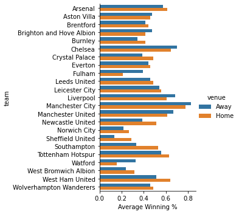

```python
sns.catplot(y = 'team', x = 'Average Winning %', data = GBmean, hue = 'venue', kind = 'bar')
```

```python
df.groupby(['team', 'venue'])['Result Number'].mean()
#Average winning % by team and venue
```

```
team                      venue
Arsenal                   Away     0.571429
                          Home     0.611111
Aston Villa               Away     0.472222
                          Home     0.455882
Brentford                 Away     0.411765
                          Home     0.441176
Brighton and Hove Albion  Away     0.472222
                          Home     0.416667
Burnley                   Away     0.342857
                          Home     0.416667
Chelsea                   Away     0.700000
                          Home     0.642857
Crystal Palace            Away     0.385714
                          Home     0.486111
Everton                   Away     0.442857
                          Home     0.457143
Fulham                    Away     0.394737
                          Home     0.210526
Leeds United              Away     0.458333
                          Home     0.485714
Leicester City            Away     0.542857
                          Home     0.557143
Liverpool                 Away     0.684211
                          Home     0.605263
Manchester City           Away     0.828571
                          Home     0.777778
Manchester United         Away     0.666667
                          Home     0.611111
Newcastle United          Away     0.388889
                          Home     0.513889
Norwich City              Away     0.218750
                          Home     0.264706
Sheffield United          Away     0.131579
                          Home     0.289474
Southampton               Away     0.333333
                          Home     0.527778
Tottenham Hotspur         Away     0.555556
                          Home     0.628571
Watford                   Away     0.323529
                          Home     0.156250
West Bromwich Albion      Away     0.236842
                          Home     0.315789
West Ham United           Away     0.513889
                          Home     0.638889
Wolverhampton Wanderers   Away     0.458333
                          Home     0.485714
Name: Result Number, dtype: float64
```

```python
df.groupby('venue')['Result Number'].mean()
#Average winning % by venue for the league
```

```
venue
Away    0.478417
Home    0.505764
Name: Result Number, dtype: float64
```

## Attendance

```python
df.corr()
```

|  | gf | ga | xg | xga | poss | attendance | notes | sh | sot | dist | fk | pk | pkatt | season | hour | dayNum | venueNum | Weekend? | Result Number | Top_6_Teams_Opp | Top_6_Teams | Month | Year | Winter? | Total Goals | Zero Goal Game | Low Scoring Game |
| --- | --- | --- | --- | --- | --- | --- | --- | --- | --- | --- | --- | --- | --- | --- | --- | --- | --- | --- | --- | --- | --- | --- | --- | --- | --- | --- | --- |
| gf | 1.000000 | -0.111446 | 0.622286 | -0.202577 | 0.169211 | 0.034719 | NaN | 0.341950 | 0.591047 | -0.146097 | 0.029429 | 0.271810 | 0.251097 | -0.010248 | -0.026044 | 0.038062 | 0.040884 | 0.032273 | 0.639259 | -0.178104 | 0.236096 | 0.032316 | -0.029109 | -0.049536 | 0.661058 | -0.295161 | -0.455018 |
| ga | -0.111446 | 1.000000 | -0.190999 | 0.629024 | -0.176823 | 0.079061 | NaN | -0.195422 | -0.164987 | 0.057408 | -0.035289 | -0.017780 | -0.013058 | 0.028516 | -0.030207 | 0.039495 | -0.037163 | 0.033181 | -0.635527 | 0.236901 | -0.158121 | 0.033362 | -0.002852 | -0.051351 | 0.671988 | -0.301211 | -0.466018 |
| xg | 0.622286 | -0.190999 | 1.000000 | -0.302950 | 0.375300 | 0.009129 | NaN | 0.697110 | 0.649701 | -0.262586 | 0.086304 | 0.310362 | 0.360882 | -0.016833 | 0.000062 | 0.025460 | 0.107386 | 0.030141 | 0.450751 | -0.219317 | 0.320006 | 0.024889 | -0.021409 | -0.045382 | 0.319519 | -0.141874 | -0.210977 |
| xga | -0.202577 | 0.629024 | -0.302950 | 1.000000 | -0.386014 | 0.062470 | NaN | -0.334899 | -0.243642 | 0.102459 | -0.092364 | -0.060077 | -0.069621 | 0.031377 | -0.003461 | 0.023663 | -0.102152 | 0.029153 | -0.456257 | 0.335862 | -0.207440 | 0.031820 | 0.006679 | -0.039143 | 0.323976 | -0.150129 | -0.213622 |
| poss | 0.169211 | -0.176823 | 0.375300 | -0.386014 | 1.000000 | -0.029415 | NaN | 0.560978 | 0.359112 | -0.075583 | 0.126875 | 0.012430 | 0.024560 | -0.026480 | 0.002826 | -0.002774 | 0.087613 | -0.002676 | 0.128832 | -0.401334 | 0.394625 | -0.005159 | -0.016137 | -0.001792 | -0.007411 | 0.006752 | 0.004078 |
| attendance | 0.034719 | 0.079061 | 0.009129 | 0.062470 | -0.029415 | 1.000000 | NaN | 0.030198 | -0.004258 | -0.005482 | -0.008841 | -0.069393 | -0.044616 | 0.548867 | -0.178102 | 0.057976 | -0.021058 | 0.072540 | -0.020834 | 0.131197 | 0.197974 | -0.048210 | 0.252184 | 0.023703 | 0.089240 | -0.068287 | -0.010500 |
| notes | NaN | NaN | NaN | NaN | NaN | NaN | NaN | NaN | NaN | NaN | NaN | NaN | NaN | NaN | NaN | NaN | NaN | NaN | NaN | NaN | NaN | NaN | NaN | NaN | NaN | NaN | NaN |
| sh | 0.341950 | -0.195422 | 0.697110 | -0.334899 | 0.560978 | 0.030198 | NaN | 1.000000 | 0.671973 | -0.125725 | 0.218640 | -0.016095 | 0.017829 | 0.039143 | 0.008468 | 0.015319 | 0.158991 | -0.003105 | 0.257833 | -0.285187 | 0.252708 | -0.005532 | 0.039652 | -0.033491 | 0.107271 | -0.020773 | -0.064023 |
| sot | 0.591047 | -0.164987 | 0.649701 | -0.243642 | 0.359112 | -0.004258 | NaN | 0.671973 | 1.000000 | -0.173293 | 0.133337 | 0.004415 | 0.014365 | -0.018545 | 0.012813 | 0.007091 | 0.089593 | -0.014161 | 0.416730 | -0.231316 | 0.244026 | 0.017258 | -0.017379 | 0.004654 | 0.315880 | -0.149527 | -0.224969 |
| dist | -0.146097 | 0.057408 | -0.262586 | 0.102459 | -0.075583 | -0.005482 | NaN | -0.125725 | -0.173293 | 1.000000 | 0.179702 | 0.176801 | 0.184683 | 0.006855 | -0.042002 | 0.044076 | -0.063665 | 0.038275 | -0.092150 | 0.092680 | -0.028924 | 0.039682 | -0.030095 | -0.016560 | -0.065530 | 0.046514 | 0.067117 |
| fk | 0.029429 | -0.035289 | 0.086304 | -0.092364 | 0.126875 | -0.008841 | NaN | 0.218640 | 0.133337 | 0.179702 | 1.000000 | -0.017371 | 0.001610 | -0.001414 | -0.018726 | 0.027903 | -0.004919 | 0.013800 | 0.029579 | -0.112851 | 0.103090 | 0.037674 | -0.026937 | 0.011825 | -0.004714 | 0.060234 | 0.030646 |
| pk | 0.271810 | -0.017780 | 0.310362 | -0.060077 | 0.012430 | -0.069393 | NaN | -0.016095 | 0.004415 | 0.176801 | -0.017371 | 1.000000 | 0.899394 | -0.045897 | -0.039753 | 0.040098 | 0.028874 | 0.045891 | 0.192192 | -0.011668 | 0.072787 | 0.070070 | -0.086663 | -0.013183 | 0.189130 | -0.095565 | -0.125672 |
| pkatt | 0.251097 | -0.013058 | 0.360882 | -0.069621 | 0.024560 | -0.044616 | NaN | 0.017829 | 0.014365 | 0.184683 | 0.001610 | 0.899394 | 1.000000 | -0.047878 | -0.039832 | 0.034118 | 0.024417 | 0.036911 | 0.165283 | -0.013784 | 0.078329 | 0.068874 | -0.085004 | -0.013152 | 0.177260 | -0.100059 | -0.114469 |
| season | -0.010248 | 0.028516 | -0.016833 | 0.031377 | -0.026480 | 0.548867 | NaN | 0.039143 | -0.018545 | 0.006855 | -0.001414 | -0.045897 | -0.047878 | 1.000000 | -0.190285 | 0.108315 | -0.000791 | 0.118474 | -0.019803 | -0.000457 | -0.041639 | 0.081549 | 0.653154 | -0.039216 | 0.013894 | -0.023233 | -0.018405 |
| hour | -0.026044 | -0.030207 | 0.000062 | -0.003461 | 0.002826 | -0.178102 | NaN | 0.008468 | 0.012813 | -0.042002 | -0.018726 | -0.039753 | -0.039832 | -0.190285 | 1.000000 | -0.605852 | -0.000158 | -0.680787 | 0.004705 | 0.006194 | 0.019097 | -0.082252 | -0.054329 | 0.088827 | -0.042216 | 0.009737 | 0.017922 |
| dayNum | 0.038062 | 0.039495 | 0.025460 | 0.023663 | -0.002774 | 0.057976 | NaN | 0.015319 | 0.007091 | 0.044076 | 0.027903 | 0.040098 | 0.034118 | 0.108315 | -0.605852 | 1.000000 | 0.001987 | 0.900890 | -0.003239 | 0.057089 | 0.058693 | 0.068657 | 0.011602 | -0.102585 | 0.058184 | -0.014021 | 0.001135 |
| venueNum | 0.040884 | -0.037163 | 0.107386 | -0.102152 | 0.087613 | -0.021058 | NaN | 0.158991 | 0.089593 | -0.063665 | -0.004919 | 0.028874 | 0.024417 | -0.000791 | -0.000158 | 0.001987 | 1.000000 | 0.001092 | 0.031104 | -0.001248 | 0.002051 | 0.002203 | -0.002229 | 0.000713 | 0.002408 | 0.000203 | 0.002070 |
| Weekend? | 0.032273 | 0.033181 | 0.030141 | 0.029153 | -0.002676 | 0.072540 | NaN | -0.003105 | -0.014161 | 0.038275 | 0.013800 | 0.045891 | 0.036911 | 0.118474 | -0.680787 | 0.900890 | 0.001092 | 1.000000 | -0.002972 | 0.047671 | 0.049094 | 0.097834 | -0.015572 | -0.120530 | 0.049103 | -0.006511 | -0.000675 |
| Result Number | 0.639259 | -0.635527 | 0.450751 | -0.456257 | 0.128832 | -0.020834 | NaN | 0.257833 | 0.416730 | -0.092150 | 0.029579 | 0.192192 | 0.165283 | -0.019803 | 0.004705 | -0.003239 | 0.031104 | -0.002972 | 1.000000 | -0.231724 | 0.236748 | 0.001989 | -0.015616 | 0.001469 | -0.003469 | 0.005072 | 0.005024 |
| Top_6_Teams_Opp | -0.178104 | 0.236901 | -0.219317 | 0.335862 | -0.401334 | 0.131197 | NaN | -0.285187 | -0.231316 | 0.092680 | -0.112851 | -0.011668 | -0.013784 | -0.000457 | 0.006194 | 0.057089 | -0.001248 | 0.047671 | -0.231724 | 1.000000 | -0.037583 | 0.013942 | -0.010207 | -0.002914 | 0.046145 | -0.034948 | -0.021597 |
| Top_6_Teams | 0.236096 | -0.158121 | 0.320006 | -0.207440 | 0.394625 | 0.197974 | NaN | 0.252708 | 0.244026 | -0.028924 | 0.103090 | 0.072787 | 0.078329 | -0.041639 | 0.019097 | 0.058693 | 0.002051 | 0.049094 | 0.236748 | -0.037583 | 1.000000 | 0.003318 | -0.032034 | 0.004281 | 0.056552 | -0.005267 | -0.009400 |
| Month | 0.032316 | 0.033362 | 0.024889 | 0.031820 | -0.005159 | -0.048210 | NaN | -0.005532 | 0.017258 | 0.039682 | 0.037674 | 0.070070 | 0.068874 | 0.081549 | -0.082252 | 0.068657 | 0.002203 | 0.097834 | 0.001989 | 0.013942 | 0.003318 | 1.000000 | -0.659814 | 0.034298 | 0.049272 | -0.009376 | -0.025978 |
| Year | -0.029109 | -0.002852 | -0.021409 | 0.006679 | -0.016137 | 0.252184 | NaN | 0.039652 | -0.017379 | -0.030095 | -0.026937 | -0.086663 | -0.085004 | 0.653154 | -0.054329 | 0.011602 | -0.002229 | -0.015572 | -0.015616 | -0.010207 | -0.032034 | -0.659814 | 1.000000 | -0.073110 | -0.023845 | -0.008222 | -0.006964 |
| Winter? | -0.049536 | -0.051351 | -0.045382 | -0.039143 | -0.001792 | 0.023703 | NaN | -0.033491 | 0.004654 | -0.016560 | 0.011825 | -0.013183 | -0.013152 | -0.039216 | 0.088827 | -0.102585 | 0.000713 | -0.120530 | 0.001469 | -0.002914 | 0.004281 | 0.034298 | -0.073110 | 1.000000 | -0.075686 | 0.052317 | 0.046640 |
| Total Goals | 0.661058 | 0.671988 | 0.319519 | 0.323976 | -0.007411 | 0.089240 | NaN | 0.107271 | 0.315880 | -0.065530 | -0.004714 | 0.189130 | 0.177260 | 0.013894 | -0.042216 | 0.058184 | 0.002408 | 0.049103 | -0.003469 | 0.046145 | 0.056552 | 0.049272 | -0.023845 | -0.075686 | 1.000000 | -0.447381 | -0.690943 |
| Zero Goal Game | -0.295161 | -0.301211 | -0.141874 | -0.150129 | 0.006752 | -0.068287 | NaN | -0.020773 | -0.149527 | 0.046514 | 0.060234 | -0.095565 | -0.100059 | -0.023233 | 0.009737 | -0.014021 | 0.000203 | -0.006511 | 0.005072 | -0.034948 | -0.005267 | -0.009376 | -0.008222 | 0.052317 | -0.447381 | 1.000000 | 0.476850 |
| Low Scoring Game | -0.455018 | -0.466018 | -0.210977 | -0.213622 | 0.004078 | -0.010500 | NaN | -0.064023 | -0.224969 | 0.067117 | 0.030646 | -0.125672 | -0.114469 | -0.018405 | 0.017922 | 0.001135 | 0.002070 | -0.000675 | 0.005024 | -0.021597 | -0.009400 | -0.025978 | -0.006964 | 0.046640 | -0.690943 | 0.476850 | 1.000000 |

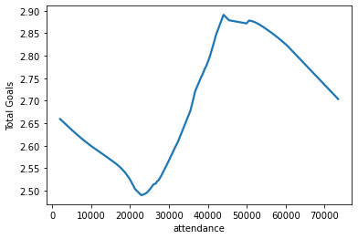

```python
sns.regplot(y = 'Total Goals', x = 'attendance' , data = df, scatter = False,lowess =True)
```

Building and filling a stadium at 45,000 tends to lead to more goals, hence more entertaining games, leading to more satisifed fans who are more likely to engage with the club.

### Mancity Attendance

```python
grouped_matches = df.groupby('team')
Mancity = grouped_matches.get_group('Manchester City')
Mancity
```

|  | date | time | comp | round | day | venue | result | gf | ga | opponent | xg | xga | poss | attendance | captain | formation | referee | match report | notes | sh | sot | dist | fk | pk | pkatt | season | team | hour | dayNum | … |
| --- | --- | --- | --- | --- | --- | --- | --- | --- | --- | --- | --- | --- | --- | --- | --- | --- | --- | --- | --- | --- | --- | --- | --- | --- | --- | --- | --- | --- | --- | --- |
| 1 | 2021-08-15 | 16:30 | Premier League | Matchweek 1 | Sun | Away | L | 0.0 | 1.0 | Tottenham | 1.9 | 1.3 | 64.0 | 58262.0 | Fernandinho | 4-3-3 | Anthony Taylor | Match Report | NaN | 18.0 | 4.0 | 16.9 | 1.0 | 0.0 | 0.0 | 2022 | Manchester City | 16 | 6 | … |
| 2 | 2021-08-21 | 15:00 | Premier League | Matchweek 2 | Sat | Home | W | 5.0 | 0.0 | Norwich City | 2.7 | 0.1 | 67.0 | 51437.0 | İlkay Gündoğan | 4-3-3 | Graham Scott | Match Report | NaN | 16.0 | 4.0 | 17.3 | 1.0 | 0.0 | 0.0 | 2022 | Manchester City | 15 | 5 | … |
| 3 | 2021-08-28 | 12:30 | Premier League | Matchweek 3 | Sat | Home | W | 5.0 | 0.0 | Arsenal | 3.8 | 0.1 | 80.0 | 52276.0 | İlkay Gündoğan | 4-3-3 | Martin Atkinson | Match Report | NaN | 25.0 | 10.0 | 14.3 | 0.0 | 0.0 | 0.0 | 2022 | Manchester City | 12 | 5 | … |
| 4 | 2021-09-11 | 15:00 | Premier League | Matchweek 4 | Sat | Away | W | 1.0 | 0.0 | Leicester City | 2.9 | 0.8 | 61.0 | 32087.0 | İlkay Gündoğan | 4-3-3 | Paul Tierney | Match Report | NaN | 25.0 | 8.0 | 14.0 | 0.0 | 0.0 | 0.0 | 2022 | Manchester City | 15 | 5 | … |
| 6 | 2021-09-18 | 15:00 | Premier League | Matchweek 5 | Sat | Home | D | 0.0 | 0.0 | Southampton | 1.1 | 0.4 | 63.0 | 52698.0 | Fernandinho | 4-3-3 | Jonathan Moss | Match Report | NaN | 16.0 | 1.0 | 15.7 | 1.0 | 0.0 | 0.0 | 2022 | Manchester City | 15 | 5 | … |
| ... | ... | ... | ... | ... | ... | ... | ... | ... | ... | ... | ... | ... | ... | ... | ... | ... | ... | ... | ... | ... | ... | ... | ... | ... | ... | ... | ... | ... | ... | … |
| 54 | 2021-05-01 | 12:30 | Premier League | Matchweek 34 | Sat | Away | W | 2.0 | 0.0 | Crystal Palace | 2.1 | 0.8 | 67.0 | NaN | Fernandinho | 4-4-1-1 | David Coote | Match Report | NaN | 20.0 | 3.0 | 14.8 | 1.0 | 0.0 | 0.0 | 2021 | Manchester City | 12 | 5 | … |
| 56 | 2021-05-08 | 17:30 | Premier League | Matchweek 35 | Sat | Home | L | 1.0 | 2.0 | Chelsea | 2.2 | 0.8 | 49.0 | NaN | Raheem Sterling | 3-5-2 | Anthony Taylor | Match Report | NaN | 15.0 | 3.0 | 19.0 | 0.0 | 0.0 | 1.0 | 2021 | Manchester City | 17 | 5 | … |
| 57 | 2021-05-14 | 20:00 | Premier League | Matchweek 36 | Fri | Away | W | 4.0 | 3.0 | Newcastle Utd | 1.3 | 2.2 | 82.0 | NaN | Raheem Sterling | 4-3-3 | Kevin Friend | Match Report | NaN | 15.0 | 6.0 | 19.0 | 1.0 | 0.0 | 0.0 | 2021 | Manchester City | 20 | 4 | … |
| 58 | 2021-05-18 | 19:00 | Premier League | Matchweek 37 | Tue | Away | L | 2.0 | 3.0 | Brighton | 1.0 | 1.4 | 37.0 | 7945.0 | İlkay Gündoğan | 4-3-3 | Stuart Attwell | Match Report | NaN | 8.0 | 4.0 | 13.2 | 1.0 | 0.0 | 0.0 | 2021 | Manchester City | 19 | 1 | … |
| 59 | 2021-05-23 | 16:00 | Premier League | Matchweek 38 | Sun | Home | W | 5.0 | 0.0 | Everton | 2.6 | 1.2 | 68.0 | 10000.0 | Fernandinho | 4-3-3 | Michael Oliver | Match Report | NaN | 21.0 | 11.0 | 15.3 | 0.0 | 0.0 | 0.0 | 2021 | Manchester City | 16 | 6 | … |

71 rows × 40 columns

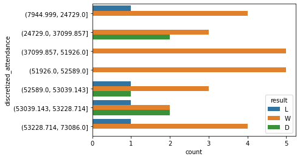

```python
Mancity['discretized_attendance'] = pd.qcut(Mancity.attendance, 7)
sns.countplot(y = 'discretized_attendance', data = Mancity, hue = 'result')
```

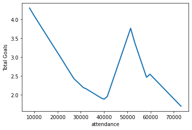

```python
sns.regplot(y = 'Total Goals', x = 'attendance' , data = Mancity, scatter = False,lowess =True)
```

Filling the Etihad Stadium at 50,000 tends to lead to more goals, hence more entertaining games, leading to more satisifed fans who are more likely to engage with the club. (The actual stadium capacity is 53,400)

### Burnley Attendance

```python
grouped_matches = df.groupby('team')
Burnley = grouped_matches.get_group('Burnley')
```

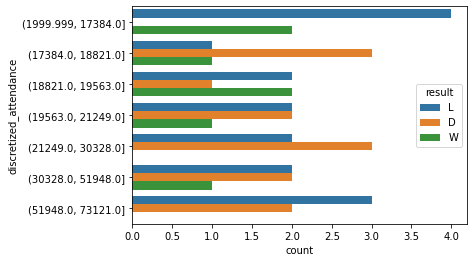

```python
Burnley['discretized_attendance'] = pd.qcut(Burnley.attendance, 7)
sns.countplot(y = 'discretized_attendance', data = Burnley, hue = 'result')
```

### Newcastle Attendance

```python
grouped_matches = df.groupby('team')
Newcastle = grouped_matches.get_group('Newcastle United')
```

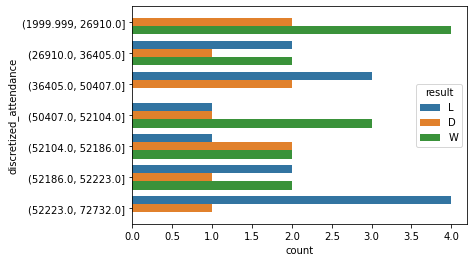

```python
Newcastle['discretized_attendance'] = pd.qcut(Newcastle.attendance, 7)
sns.countplot(y = 'discretized_attendance', data = Newcastle, hue = 'result')
```

### Wolves Attendance

```python
grouped_matches = df.groupby('team')
Wolves = grouped_matches.get_group('Wolverhampton Wanderers')
```

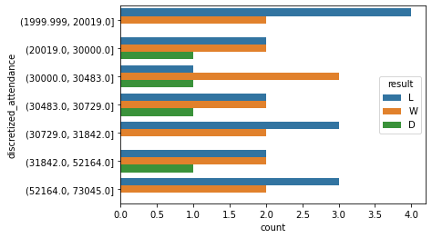

```python
Wolves['discretized_attendance'] = pd.qcut(Wolves.attendance, 7)
sns.countplot(y = 'discretized_attendance', data = Wolves, hue = 'result')
```

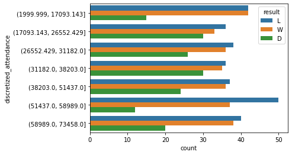

```python
df['discretized_attendance'] = pd.qcut(df.attendance, 7)
sns.countplot(y = 'discretized_attendance', data = df, hue = 'result')
```

```python
#Shows that Total attendance won't matter too much
```

```python
df
```

|  | date | time | comp | round | day | venue | result | gf | ga | opponent | xg | xga | poss | attendance | captain | formation | referee | match report | notes | sh | sot | dist | fk | pk | pkatt | season | team | hour | dayNum | … |
| --- | --- | --- | --- | --- | --- | --- | --- | --- | --- | --- | --- | --- | --- | --- | --- | --- | --- | --- | --- | --- | --- | --- | --- | --- | --- | --- | --- | --- | --- | --- |
| 1 | 2021-08-15 | 16:30 | Premier League | Matchweek 1 | Sun | Away | L | 0.0 | 1.0 | Tottenham | 1.9 | 1.3 | 64.0 | 58262.0 | Fernandinho | 4-3-3 | Anthony Taylor | Match Report | NaN | 18.0 | 4.0 | 16.9 | 1.0 | 0.0 | 0.0 | 2022 | Manchester City | 16 | 6 | … |
| 2 | 2021-08-21 | 15:00 | Premier League | Matchweek 2 | Sat | Home | W | 5.0 | 0.0 | Norwich City | 2.7 | 0.1 | 67.0 | 51437.0 | İlkay Gündoğan | 4-3-3 | Graham Scott | Match Report | NaN | 16.0 | 4.0 | 17.3 | 1.0 | 0.0 | 0.0 | 2022 | Manchester City | 15 | 5 | … |
| 3 | 2021-08-28 | 12:30 | Premier League | Matchweek 3 | Sat | Home | W | 5.0 | 0.0 | Arsenal | 3.8 | 0.1 | 80.0 | 52276.0 | İlkay Gündoğan | 4-3-3 | Martin Atkinson | Match Report | NaN | 25.0 | 10.0 | 14.3 | 0.0 | 0.0 | 0.0 | 2022 | Manchester City | 12 | 5 | … |
| 4 | 2021-09-11 | 15:00 | Premier League | Matchweek 4 | Sat | Away | W | 1.0 | 0.0 | Leicester City | 2.9 | 0.8 | 61.0 | 32087.0 | İlkay Gündoğan | 4-3-3 | Paul Tierney | Match Report | NaN | 25.0 | 8.0 | 14.0 | 0.0 | 0.0 | 0.0 | 2022 | Manchester City | 15 | 5 | … |
| 6 | 2021-09-18 | 15:00 | Premier League | Matchweek 5 | Sat | Home | D | 0.0 | 0.0 | Southampton | 1.1 | 0.4 | 63.0 | 52698.0 | Fernandinho | 4-3-3 | Jonathan Moss | Match Report | NaN | 16.0 | 1.0 | 15.7 | 1.0 | 0.0 | 0.0 | 2022 | Manchester City | 15 | 5 | … |
| ... | ... | ... | ... | ... | ... | ... | ... | ... | ... | ... | ... | ... | ... | ... | ... | ... | ... | ... | ... | ... | ... | ... | ... | ... | ... | ... | ... | ... | ... | … |
| 38 | 2021-05-02 | 19:15 | Premier League | Matchweek 34 | Sun | Away | L | 0.0 | 4.0 | Tottenham | 0.5 | 2.0 | 34.0 | NaN | John Egan | 3-4-1-2 | Andre Marriner | Match Report | NaN | 8.0 | 1.0 | 17.4 | 0.0 | 0.0 | 0.0 | 2021 | Sheffield United | 19 | 6 | … |
| 39 | 2021-05-08 | 15:00 | Premier League | Matchweek 35 | Sat | Home | L | 0.0 | 2.0 | Crystal Palace | 0.7 | 2.1 | 50.0 | NaN | John Egan | 3-5-2 | Simon Hooper | Match Report | NaN | 7.0 | 0.0 | 11.4 | 1.0 | 0.0 | 0.0 | 2021 | Sheffield United | 15 | 5 | … |
| 40 | 2021-05-16 | 19:00 | Premier League | Matchweek 36 | Sun | Away | W | 1.0 | 0.0 | Everton | 1.6 | 1.3 | 38.0 | NaN | John Egan | 3-4-3 | Jonathan Moss | Match Report | NaN | 10.0 | 3.0 | 17.0 | 0.0 | 0.0 | 0.0 | 2021 | Sheffield United | 19 | 6 | … |
| 41 | 2021-05-19 | 18:00 | Premier League | Matchweek 37 | Wed | Away | L | 0.0 | 1.0 | Newcastle Utd | 0.8 | 1.5 | 50.0 | 10000.0 | John Egan | 3-4-3 | Robert Jones | Match Report | NaN | 11.0 | 1.0 | 16.0 | 1.0 | 0.0 | 0.0 | 2021 | Sheffield United | 18 | 2 | … |
| 42 | 2021-05-23 | 16:00 | Premier League | Matchweek 38 | Sun | Home | W | 1.0 | 0.0 | Burnley | 0.6 | 1.0 | 41.0 | 5000.0 | John Egan | 3-4-3 | Kevin Friend | Match Report | NaN | 12.0 | 3.0 | 17.0 | 0.0 | 0.0 | 0.0 | 2021 | Sheffield United | 16 | 6 | … |

1389 rows × 41 columns

# Winter Season??

To Club Owner: Games in winter tend to have less goals than non winter months.

```python
df.groupby('Winter?')['Total Goals'].agg(['mean','sum'])
#Overall League: Average and Total Goals scored in Winter/ non Winter months
```

| Winter? | mean | sum |
| --- | --- | --- |
| 0 | 2.844508 | 1994.0 |
| 1 | 2.585756 | 1779.0 |

```python
df.groupby(['team','Winter?'])['Total Goals'].agg(['mean','sum'])
#By Teams: Average and Total Goals scored in Winter/ non Winter months
```

| team | Winter? | mean | sum |
| --- | --- | --- | --- |
| Arsenal | 0 | 2.702703 | 100.0 |
|  | 1 | 2.529412 | 86.0 |
| Aston Villa | 0 | 2.916667 | 105.0 |
|  | 1 | 2.470588 | 84.0 |
| Brentford | 0 | 2.529412 | 43.0 |
|  | 1 | 2.764706 | 47.0 |
| Brighton and Hove Albion | 0 | 2.472222 | 89.0 |
|  | 1 | 1.944444 | 70.0 |
| Burnley | 0 | 2.675676 | 99.0 |
|  | 1 | 1.852941 | 63.0 |
| Chelsea | 0 | 3.027778 | 109.0 |
|  | 1 | 2.323529 | 79.0 |
| Crystal Palace | 0 | 2.571429 | 90.0 |
|  | 1 | 2.805556 | 101.0 |
| Everton | 0 | 2.621622 | 97.0 |
|  | 1 | 2.636364 | 87.0 |
| Fulham | 0 | 2.555556 | 46.0 |
|  | 1 | 1.700000 | 34.0 |
| Leeds United | 0 | 2.685714 | 94.0 |
|  | 1 | 3.555556 | 128.0 |
| Leicester City | 0 | 3.081081 | 114.0 |
|  | 1 | 3.090909 | 102.0 |
| Liverpool | 0 | 3.210526 | 61.0 |
|  | 1 | 2.578947 | 49.0 |
| Manchester City | 0 | 3.235294 | 110.0 |
|  | 1 | 2.864865 | 106.0 |
| Manchester United | 0 | 3.323529 | 113.0 |
|  | 1 | 2.842105 | 108.0 |
| Newcastle United | 0 | 3.000000 | 111.0 |
|  | 1 | 2.628571 | 92.0 |
| Norwich City | 0 | 2.882353 | 49.0 |
|  | 1 | 2.625000 | 42.0 |
| Sheffield United | 0 | 2.000000 | 38.0 |
|  | 1 | 2.368421 | 45.0 |
| Southampton | 0 | 2.864865 | 106.0 |
|  | 1 | 3.000000 | 105.0 |
| Tottenham Hotspur | 0 | 3.270270 | 121.0 |
|  | 1 | 2.529412 | 86.0 |
| Watford | 0 | 3.294118 | 56.0 |
|  | 1 | 2.625000 | 42.0 |
| West Bromwich Albion | 0 | 3.111111 | 56.0 |
|  | 1 | 2.750000 | 55.0 |
| West Ham United | 0 | 3.000000 | 108.0 |
|  | 1 | 2.694444 | 97.0 |
| Wolverhampton Wanderers | 0 | 2.257143 | 79.0 |
|  | 1 | 1.972222 | 71.0 |

```python
df.groupby('Winter?')['Zero Goal Game'].agg(['mean','sum'])
#Overall League: Average and total amount of Zero Goal Games in Winter/ non Winter months
```

| Winter? | mean | sum |
| --- | --- | --- |
| 0 | 0.059914 | 42 |
| 1 | 0.087209 | 60 |

```python
df.groupby(['team','Winter?'])['Zero Goal Game'].agg(['mean','sum'])
#By Teams: Average and total amount of Zero Goal Games in Winter/ non Winter months
```

| team | Winter? | mean | sum |
| --- | --- | --- | --- |
| Arsenal | 0 | 0.027027 | 1 |
|  | 1 | 0.117647 | 4 |
| Aston Villa | 0 | 0.083333 | 3 |
|  | 1 | 0.058824 | 2 |
| Brentford | 0 | 0.117647 | 2 |
|  | 1 | 0.058824 | 1 |
| Brighton and Hove Albion | 0 | 0.138889 | 5 |
|  | 1 | 0.138889 | 5 |
| Burnley | 0 | 0.054054 | 2 |
|  | 1 | 0.205882 | 7 |
| Chelsea | 0 | 0.083333 | 3 |
|  | 1 | 0.117647 | 4 |
| Crystal Palace | 0 | 0.114286 | 4 |
|  | 1 | 0.083333 | 3 |
| Everton | 0 | 0.054054 | 2 |
|  | 1 | 0.030303 | 1 |
| Fulham | 0 | 0.000000 | 0 |
|  | 1 | 0.250000 | 5 |
| Leeds United | 0 | 0.085714 | 3 |
|  | 1 | 0.055556 | 2 |
| Leicester City | 0 | 0.027027 | 1 |
|  | 1 | 0.030303 | 1 |
| Liverpool | 0 | 0.000000 | 0 |
|  | 1 | 0.105263 | 2 |
| Manchester City | 0 | 0.058824 | 2 |
|  | 1 | 0.027027 | 1 |
| Manchester United | 0 | 0.088235 | 3 |
|  | 1 | 0.131579 | 5 |
| Newcastle United | 0 | 0.027027 | 1 |
|  | 1 | 0.028571 | 1 |
| Norwich City | 0 | 0.176471 | 3 |
|  | 1 | 0.062500 | 1 |
| Sheffield United | 0 | 0.000000 | 0 |
|  | 1 | 0.000000 | 0 |
| Southampton | 0 | 0.054054 | 2 |
|  | 1 | 0.057143 | 2 |
| Tottenham Hotspur | 0 | 0.027027 | 1 |
|  | 1 | 0.058824 | 2 |
| Watford | 0 | 0.000000 | 0 |
|  | 1 | 0.125000 | 2 |
| West Bromwich Albion | 0 | 0.111111 | 2 |
|  | 1 | 0.050000 | 1 |
| West Ham United | 0 | 0.027778 | 1 |
|  | 1 | 0.083333 | 3 |
| Wolverhampton Wanderers | 0 | 0.028571 | 1 |
|  | 1 | 0.138889 | 5 |

```python
df.groupby('Winter?')['Low Scoring Game'].agg(['mean','sum'])
#Overall League: Average and total amount of Low Scoring Games in Winter/ non Winter months
```

| Winter? | mean | sum |
| --- | --- | --- |
| 0 | 0.238231 | 167 |
| 1 | 0.279070 | 192 |

```python
df.groupby(['team','Winter?'])['Low Scoring Game'].agg(['mean','sum'])
#By Team: Average and total amount of Low Scoring Games in Winter/ non Winter months
```

| team | Winter? | mean | sum |
| --- | --- | --- | --- |
| Arsenal | 0 | 0.243243 | 9 |
|  | 1 | 0.323529 | 11 |
| Aston Villa | 0 | 0.222222 | 8 |
|  | 1 | 0.323529 | 11 |
| Brentford | 0 | 0.235294 | 4 |
|  | 1 | 0.176471 | 3 |
| Brighton and Hove Albion | 0 | 0.222222 | 8 |
|  | 1 | 0.333333 | 12 |
| Burnley | 0 | 0.189189 | 7 |
|  | 1 | 0.500000 | 17 |
| Chelsea | 0 | 0.277778 | 10 |
|  | 1 | 0.264706 | 9 |
| Crystal Palace | 0 | 0.200000 | 7 |
|  | 1 | 0.222222 | 8 |
| Everton | 0 | 0.351351 | 13 |
|  | 1 | 0.242424 | 8 |
| Fulham | 0 | 0.222222 | 4 |
|  | 1 | 0.400000 | 8 |
| Leeds United | 0 | 0.228571 | 8 |
|  | 1 | 0.250000 | 9 |
| Leicester City | 0 | 0.162162 | 6 |
|  | 1 | 0.090909 | 3 |
| Liverpool | 0 | 0.157895 | 3 |
|  | 1 | 0.263158 | 5 |
| Manchester City | 0 | 0.205882 | 7 |
|  | 1 | 0.243243 | 9 |
| Manchester United | 0 | 0.205882 | 7 |
|  | 1 | 0.342105 | 13 |
| Newcastle United | 0 | 0.162162 | 6 |
|  | 1 | 0.142857 | 5 |
| Norwich City | 0 | 0.235294 | 4 |
|  | 1 | 0.125000 | 2 |
| Sheffield United | 0 | 0.473684 | 9 |
|  | 1 | 0.368421 | 7 |
| Southampton | 0 | 0.243243 | 9 |
|  | 1 | 0.171429 | 6 |
| Tottenham Hotspur | 0 | 0.243243 | 9 |
|  | 1 | 0.205882 | 7 |
| Watford | 0 | 0.176471 | 3 |
|  | 1 | 0.375000 | 6 |
| West Bromwich Albion | 0 | 0.222222 | 4 |
|  | 1 | 0.250000 | 5 |
| West Ham United | 0 | 0.222222 | 8 |
|  | 1 | 0.305556 | 11 |
| Wolverhampton Wanderers | 0 | 0.400000 | 14 |
|  | 1 | 0.472222 | 17 |

## Zero Goal Games

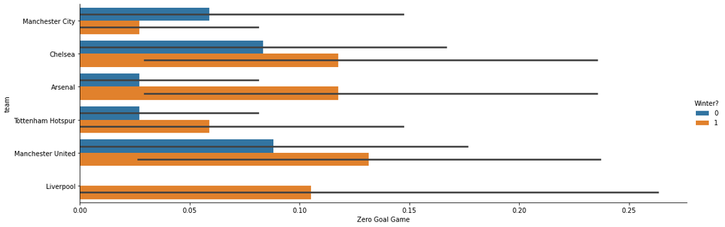

```python
sns.catplot(y = 'team',x = 'Zero Goal Game',hue = 'Winter?', data = Top_6, aspect = 3, kind = 'bar')
#TOP 6 TEAMS
```

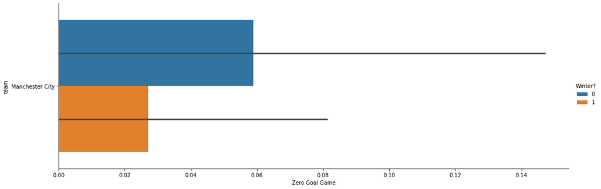

```python
sns.catplot(y = 'team',x = 'Zero Goal Game',hue = 'Winter?', data = Mancity, aspect = 3, kind = 'bar')
```

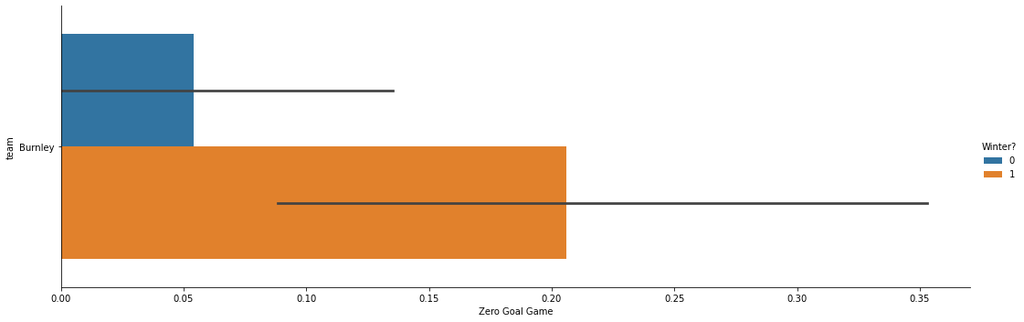

```python
sns.catplot(y = 'team',x = 'Zero Goal Game',hue = 'Winter?', data = Burnley, aspect = 3, kind = 'bar')
```

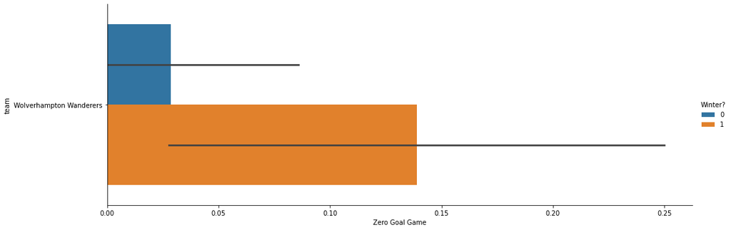

```python
sns.catplot(y = 'team',x = 'Zero Goal Game',hue = 'Winter?', data = Wolves, aspect = 3, kind = 'bar')
```

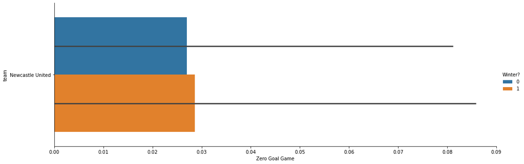

```python
sns.catplot(y = 'team',x = 'Zero Goal Game',hue = 'Winter?', data = Newcastle, aspect = 3, kind = 'bar')
```

## Low Scoring Games

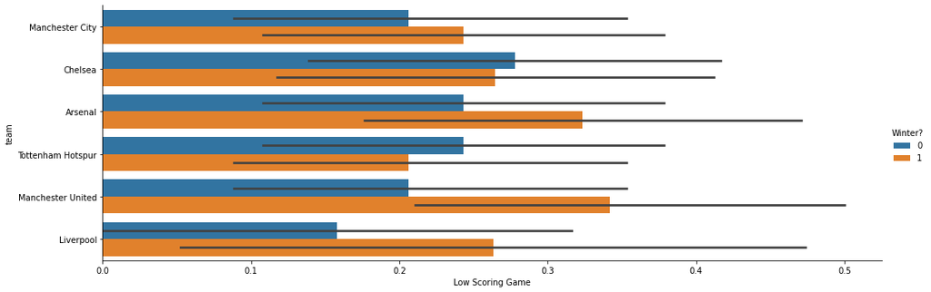

```python
sns.catplot(y = 'team',x = 'Low Scoring Game',hue = 'Winter?', data = Top_6, aspect = 3, kind = 'bar')
```

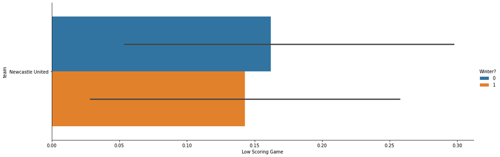

```python
sns.catplot(y = 'team',x = 'Low Scoring Game',hue = 'Winter?', data = Newcastle, aspect = 3, kind = 'bar')
```

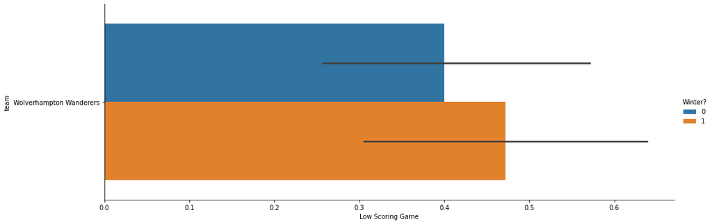

```python
sns.catplot(y = 'team',x = 'Low Scoring Game',hue = 'Winter?', data = Wolves, aspect = 3, kind = 'bar')
```

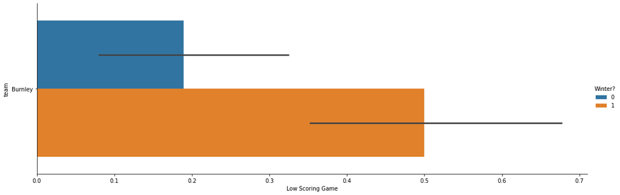

```python
sns.catplot(y = 'team',x = 'Low Scoring Game',hue = 'Winter?', data = Burnley, aspect = 3, kind = 'bar')
```

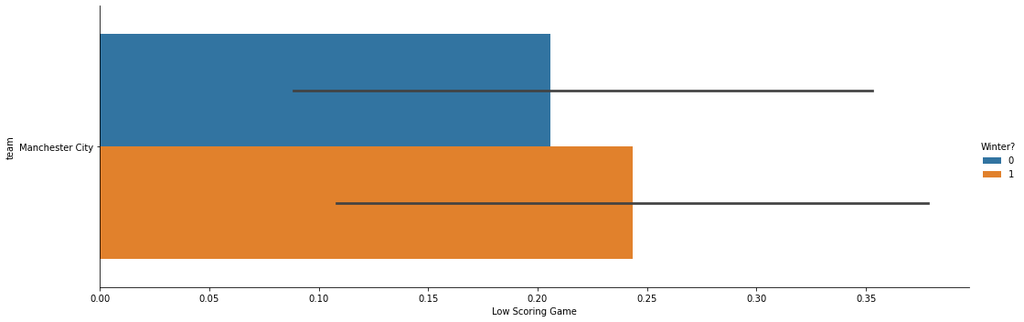

```python
sns.catplot(y = 'team',x = 'Low Scoring Game',hue = 'Winter?', data = Mancity, aspect = 3, kind = 'bar')
```

# Insight 3 (ML): What factors affect season position?

To Club Owners: Factors such as Net Transfer Count, Net Spending, Win count, Draw count, Loss count, Goals for, Goals Against, Goal Differntial, and the amount of points you gain in the season determine your position at the end of the season.

```python
premdf = pd.read_csv("premier-league.csv", index_col=0)
```

### Dataset ("premier-league.csv") Description

The data set has:

• One row for each transfer made within the Premier league from 1992 to 2022  
• The following columns: club_name, player_name, age, position, club_involved_name, fee, transfer_movement, transfer_period, fee_cleaned (fee without currency symbol), league_name, year, and season.

```python
premdf
premdf.shape
```

| club_name | player_name | age | position | club_involved_name | fee | transfer_movement | transfer_period | fee_cleaned | league_name | year | season |
| --- | --- | --- | --- | --- | --- | --- | --- | --- | --- | --- | --- |
| Middlesbrough FC | Tommy Wright | 26.0 | Left Winger | Leicester | €910Th. | in | Summer | 0.91 | Premier League | 1992 | 1992/1993 |
| Middlesbrough FC | Jonathan Gittens | 28.0 | defence | Southampton | €250Th. | in | Summer | 0.25 | Premier League | 1992 | 1992/1993 |
| Middlesbrough FC | Chris Morris | 28.0 | Right-Back | Celtic | ? | in | Summer | NaN | Premier League | 1992 | 1992/1993 |
| Middlesbrough FC | Ben Roberts | 17.0 | Goalkeeper | Boro U18 | - | in | Summer | NaN | Premier League | 1992 | 1992/1993 |
| Middlesbrough FC | Andy Todd | 17.0 | Centre-Back | Boro U18 | - | in | Summer | NaN | Premier League | 1992 | 1992/1993 |
| ... | ... | ... | ... | ... | ... | ... | ... | ... | ... | ... | ... |
| Wolverhampton Wanderers | Luke Cundle | 20.0 | Central Midfield | Swansea | loan transfer | out | summer | NaN | Premier League | 2022 | 2022/2023 |
| Wolverhampton Wanderers | Fábio Silva | 20.0 | Centre-Forward | RSC Anderlecht | loan transfer | out | summer | NaN | Premier League | 2022 | 2022/2023 |
| Wolverhampton Wanderers | Ki-Jana Hoever | 20.0 | Right-Back | PSV Eindhoven | loan transfer | out | summer | NaN | Premier League | 2022 | 2022/2023 |
| Wolverhampton Wanderers | Hee-chan Hwang | 26.0 | Centre-Forward | RB Leipzig | End of loanJun 30, 2022 | out | summer | NaN | Premier League | 2022 | 2022/2023 |
| Wolverhampton Wanderers | Francisco Trincão | 22.0 | Right Winger | Barcelona | End of loanJun 30, 2022 | out | summer | NaN | Premier League | 2022 | 2022/2023 |

23498 rows × 11 columns

```
(23498, 11)
```

### Data Cleaning ("premier-league.csv")

```python
#Cutting df to only include seasons from 2000-2021
above2000= premdf[premdf["year"] > 1999]
above2000_below2022 = above2000[above2000["year"] < 2022]
premdf = above2000_below2022
premdf
```

| club_name | player_name | age | position | club_involved_name | fee | transfer_movement | transfer_period | fee_cleaned | league_name | year | season |
| --- | --- | --- | --- | --- | --- | --- | --- | --- | --- | --- | --- |
| Leeds United | Olivier Dacourt | 25.0 | Defensive Midfield | Lens | €10.50m | in | Summer | 10.500 | Premier League | 2000 | 2000/2001 |
| Leeds United | Mark Viduka | 24.0 | Centre-Forward | Celtic | €9.15m | in | Summer | 9.150 | Premier League | 2000 | 2000/2001 |
| Leeds United | Dominic Matteo | 26.0 | Left-Back | Liverpool | €7.13m | in | Summer | 7.130 | Premier League | 2000 | 2000/2001 |
| Leeds United | Jacob Burns | 22.0 | Defensive Midfield | Parra. Power | €375Th. | in | Summer | 0.375 | Premier League | 2000 | 2000/2001 |
| Leeds United | Jamie McMaster | 17.0 | Central Midfield | NSWIS | free transfer | in | Summer | 0.000 | Premier League | 2000 | 2000/2001 |
| ... | ... | ... | ... | ... | ... | ... | ... | ... | ... | ... | ... |
| Wolverhampton Wanderers | Hayao Kawabe | 26.0 | Central Midfield | Grasshoppers | loan transfer | out | Winter | NaN | Premier League | 2021 | 2021/2022 |
| Wolverhampton Wanderers | Sang-bin Jeong | 19.0 | Right Winger | Grasshoppers | loan transfer | out | Winter | NaN | Premier League | 2021 | 2021/2022 |
| Wolverhampton Wanderers | Adama Traoré | 26.0 | Right Winger | Barcelona | loan transfer | out | Winter | NaN | Premier League | 2021 | 2021/2022 |
| Wolverhampton Wanderers | Bruno Jordão | 23.0 | Central Midfield | Grasshoppers | loan transfer | out | Winter | NaN | Premier League | 2021 | 2021/2022 |
| Wolverhampton Wanderers | Oskar Buur | 23.0 | Right-Back | Without Club | - | out | Winter | NaN | Premier League | 2021 | 2021/2022 |

18628 rows × 11 columns

```python
#Dropping Unneccesary Columns
premdf.drop(columns = ['player_name','age','position','club_involved_name','fee','league_name','year','transfer_period'],inplace = True)
```

```python
#Renaming the columns
premdf.reset_index(inplace = True)
premdf.rename(columns = {'club_name':'Team','transfer_movement':'Transfer Movement',
                              'fee_cleaned':'Fee','season':'Season_Change'}, inplace = True)
premdf
```

|  | Team | Transfer Movement | Fee | Season_Change |
| --- | --- | --- | --- | --- |
| 0 | Leeds United | in | 10.500 | 2000/2001 |
| 1 | Leeds United | in | 9.150 | 2000/2001 |
| 2 | Leeds United | in | 7.130 | 2000/2001 |
| 3 | Leeds United | in | 0.375 | 2000/2001 |
| 4 | Leeds United | in | 0.000 | 2000/2001 |
| ... | ... | ... | ... | ... |
| 18623 | Wolverhampton Wanderers | out | NaN | 2021/2022 |
| 18624 | Wolverhampton Wanderers | out | NaN | 2021/2022 |
| 18625 | Wolverhampton Wanderers | out | NaN | 2021/2022 |
| 18626 | Wolverhampton Wanderers | out | NaN | 2021/2022 |
| 18627 | Wolverhampton Wanderers | out | NaN | 2021/2022 |

18628 rows × 4 columns

```python
premdf['Team'].unique()
premdf['Team'].nunique()
```

```
array(['Leeds United', 'Bradford City', 'Leicester City', 'Coventry City',
       'Manchester United', 'Newcastle United', 'Ipswich Town',
       'Middlesbrough FC', 'Chelsea FC', 'Aston Villa', 'Arsenal FC',
       'West Ham United', 'Charlton Athletic', 'Sunderland AFC',
       'Manchester City', 'Southampton FC', 'Tottenham Hotspur',
       'Liverpool FC', 'Everton FC', 'Derby County', 'Fulham FC',
       'Bolton Wanderers', 'Blackburn Rovers', 'West Bromwich Albion',
       'Birmingham City', 'Portsmouth FC', 'Wolverhampton Wanderers',
       'Norwich City', 'Crystal Palace', 'Wigan Athletic', 'Reading FC',
       'Sheffield United', 'Watford FC', 'Stoke City', 'Hull City',
       'Burnley FC', 'Blackpool FC', 'Queens Park Rangers',
       'Swansea City', 'Cardiff City', 'AFC Bournemouth',
       'Brighton & Hove Albion', 'Huddersfield Town', 'Brentford FC'],
      dtype=object)
```

```
44
```

```python
premdf['Team'] = premdf['Team'].replace({'Middlesbrough FC':'Middlesbrough','Chelsea FC':'Chelsea','Arsenal FC':'Arsenal',
     'Sunderland AFC': 'Sunderland', 'Southampton FC': 'Southampton', 'Liverpool FC':'Liverpool',  'Everton FC':'Everton',
      'Fulham FC':'Fulham','Portsmouth FC':'Portsmouth','Reading FC':'Reading','Watford FC':'Watford', 'Burnley FC':'Burnley',
      'Blackpool FC':'Blackpool','AFC Bournemouth':'Bournemouth', 'Brentford FC':'Brentford' })
```

```python
premdf['Team'].unique()
premdf['Team'].nunique()
```

```
array(['Leeds United', 'Bradford City', 'Leicester City', 'Coventry City',
       'Manchester United', 'Newcastle United', 'Ipswich Town',
       'Middlesbrough', 'Chelsea', 'Aston Villa', 'Arsenal',
       'West Ham United', 'Charlton Athletic', 'Sunderland',
       'Manchester City', 'Southampton', 'Tottenham Hotspur', 'Liverpool',
       'Everton', 'Derby County', 'Fulham', 'Bolton Wanderers',
       'Blackburn Rovers', 'West Bromwich Albion', 'Birmingham City',
       'Portsmouth', 'Wolverhampton Wanderers', 'Norwich City',
       'Crystal Palace', 'Wigan Athletic', 'Reading', 'Sheffield United',
       'Watford', 'Stoke City', 'Hull City', 'Burnley', 'Blackpool',
       'Queens Park Rangers', 'Swansea City', 'Cardiff City',
       'Bournemouth', 'Brighton & Hove Albion', 'Huddersfield Town',
       'Brentford'], dtype=object)
```

```
44
```

```python
#Changing Season format to match "EPL Standings 2000-2022.csv" Season Column
def formatchange(Season):
    if Season == '2000/2001':
        return '2000-01'
    elif Season == '2001/2002':
        return '2001-02'
    elif Season == '2002/2003':
        return '2002-03'
    elif Season == '2003/2004':
        return '2003-04'
    elif Season == '2004/2005':
        return '2004-05'
    elif Season == '2005/2006':
        return '2005-06'
    elif Season == '2006/2007':
        return '2006-07'
    elif Season == '2007/2008':
        return '2007-08'
    elif Season == '2008/2009':
        return '2008-09'
    elif Season == '2009/2010':
        return '2009-10'
    elif Season == '2010/2011':
        return '2010-11'
    elif Season == '2011/2012':
        return '2011-12'
    elif Season == '2012/2013':
        return '2012-13'
    elif Season =='2013/2014':
        return '2013-14'
    elif Season =='2014/2015':
        return '2014-15'
    elif Season =='2015/2016':
        return '2015-16'
    elif Season =='2016/2017':
        return '2016-17'
    elif Season =='2017/2018':
        return '2017-18'
    elif Season =='2018/2019':
        return '2018-19'
    elif Season =='2019/2020':
        return '2019-20'
    elif Season =='2020/2021':
        return '2020-21'
    elif Season =='2021/2022':
        return '2021-22'
    else:
        return 'N/A'
premdf['Season'] = premdf['Season_Change'].apply(formatchange)
```

```python
premdf.drop(columns = ['Season_Change'],inplace = True)
```

```python
# Create Net Spend Columns and Net Transfer Count
GBpremdf = premdf.groupby(['Team','Season', 'Transfer Movement' ]).agg({'sum','count'})
GBpremdf.head(10)
premdf = GBpremdf.diff(-1).iloc[::2]
premdf.rename(columns = {'count': 'Net Transfer Count','sum':"Net Spending"},inplace = True)
```

| Team | Season | Transfer Movement | Fee count | Fee sum |
| --- | --- | --- | --- | --- |
| Arsenal | 2000-01 | in | 8 | 56.300 |
|  |  | out | 8 | 49.525 |
|  | 2001-02 | in | 8 | 32.685 |
|  |  | out | 6 | 12.000 |
|  | 2002-03 | in | 3 | 12.830 |
|  |  | out | 5 | 8.220 |
|  | 2003-04 | in | 5 | 27.425 |
|  |  | out | 10 | 1.050 |
|  | 2004-05 | in | 5 | 12.480 |
|  |  | out | 10 | 3.900 |

```python
premdf
```

| Team | Season | Transfer Movement | Fee Net Transfer Count | Fee Net Spending |
| --- | --- | --- | --- | --- |
| Arsenal | 2000-01 | in | 0.0 | 6.775 |
|  | 2001-02 | in | 2.0 | 20.685 |
|  | 2002-03 | in | -2.0 | 4.610 |
|  | 2003-04 | in | -5.0 | 26.375 |
|  | 2004-05 | in | -5.0 | 8.580 |
| ... | ... | ... | ... | ... |
| Wolverhampton Wanderers | 2011-12 | in | -4.0 | 9.445 |
|  | 2018-19 | in | 2.0 | 89.450 |
|  | 2019-20 | in | 0.0 | 92.600 |
|  | 2020-21 | in | 1.0 | 8.600 |
|  | 2021-22 | in | 6.0 | 5.800 |

440 rows × 2 columns

```python
premdf.tail(50)
```

| Team | Season | Transfer Movement | Fee Net Transfer Count | Fee Net Spending |
| --- | --- | --- | --- | --- |
| Watford | 2019-20 | in | 3.0 | 23.100 |
|  | 2021-22 | in | 5.0 | 30.650 |
| West Bromwich Albion | 2002-03 | in | 3.0 | 16.950 |
|  | 2004-05 | in | -2.0 | 13.900 |
|  | 2005-06 | in | -4.0 | 6.220 |
|  | 2008-09 | in | 3.0 | 14.070 |
|  | 2010-11 | in | 4.0 | 12.980 |
|  | 2011-12 | in | -1.0 | -1.982 |
|  | 2012-13 | in | -4.0 | 1.270 |
|  | 2013-14 | in | -2.0 | 4.300 |
|  | 2014-15 | in | 3.0 | 22.580 |
|  | 2015-16 | in | -1.0 | 29.980 |
|  | 2016-17 | in | -2.0 | 10.925 |
|  | 2017-18 | in | 4.0 | 51.450 |
|  | 2020-21 | in | 3.0 | 34.040 |
| West Ham United | 2000-01 | in | 0.0 | -23.744 |
|  | 2001-02 | in | -3.0 | 3.930 |
|  | 2002-03 | in | -1.0 | 0.325 |
|  | 2005-06 | in | 0.0 | 21.040 |
|  | 2006-07 | in | 2.0 | 63.110 |
|  | 2007-08 | in | -3.0 | 5.150 |
|  | 2008-09 | in | -8.0 | -52.830 |
|  | 2009-10 | in | 2.0 | -19.650 |
|  | 2010-11 | in | 4.0 | 13.075 |
|  | 2012-13 | in | 1.0 | 18.845 |
|  | 2013-14 | in | 2.0 | 23.470 |
|  | 2014-15 | in | 0.0 | 30.750 |
|  | 2015-16 | in | -1.0 | 34.180 |
|  | 2016-17 | in | 11.0 | 42.500 |
|  | 2017-18 | in | -3.0 | -12.220 |
|  | 2018-19 | in | 6.0 | 87.135 |
|  | 2019-20 | in | -4.0 | 64.320 |
|  | 2020-21 | in | 0.0 | 9.290 |
|  | 2021-22 | in | 1.0 | 70.265 |
| Wigan Athletic | 2005-06 | in | 1.0 | 10.145 |
|  | 2006-07 | in | 5.0 | 5.050 |
|  | 2007-08 | in | 4.0 | 0.070 |
|  | 2008-09 | in | -4.0 | -0.400 |
|  | 2009-10 | in | 3.0 | -7.545 |
|  | 2010-11 | in | -1.0 | 8.000 |
|  | 2011-12 | in | 3.0 | 1.095 |
|  | 2012-13 | in | -3.0 | -2.715 |
| Wolverhampton Wanderers | 2003-04 | in | 0.0 | 8.725 |
|  | 2009-10 | in | 2.0 | 18.580 |
|  | 2010-11 | in | 1.0 | 13.775 |
|  | 2011-12 | in | -4.0 | 9.445 |
|  | 2018-19 | in | 2.0 | 89.450 |
|  | 2019-20 | in | 0.0 | 92.600 |
|  | 2020-21 | in | 1.0 | 8.600 |
|  | 2021-22 | in | 6.0 | 5.800 |

```python
df = pd.read_csv("EPL Standings 2000-2022.csv", index_col=0)
df.shape
df.head()
```

```
(440, 11)
```

| Season | Pos | Team | Pld | W | D | L | GF | GA | GD | Pts | Qualification or relegation |
| --- | --- | --- | --- | --- | --- | --- | --- | --- | --- | --- | --- |
| 2000-01 | 1 | Manchester United | 38 | 24 | 8 | 6 | 79 | 31 | 48 | 80 | Qualification for the Champions League first g... |
| 2000-01 | 2 | Arsenal | 38 | 20 | 10 | 8 | 63 | 38 | 25 | 70 | Qualification for the Champions League first g... |
| 2000-01 | 3 | Liverpool | 38 | 20 | 9 | 9 | 71 | 39 | 32 | 69 | Qualification for the Champions League third q... |
| 2000-01 | 4 | Leeds United | 38 | 20 | 8 | 10 | 64 | 43 | 21 | 68 | Qualification for the UEFA Cup first round[a] |
| 2000-01 | 5 | Ipswich Town | 38 | 20 | 6 | 12 | 57 | 42 | 15 | 66 | Qualification for the UEFA Cup first round[a] |

### Dataset ( "EPL Standings 2000-2022.csv") description

Meaning of each column :

Season -- Year in which the league was

Pos -- Team position in the league

Team -- Team name

Pld -- Games played

W -- Games won

D -- Games tied

L -- Games lost

GF -- Goals for

GA -- Goals against

GD -- Goal difference

Pts -- Points won (Win = 3 pts, D= 1pt, L = 0pts)

Qualification or relegation -- Qualification to Europe Cups or relegation to Football League First Division

Each row represents a team and their statisitcs within a particular season. n.

## Dataset Cleaning ( "EPL Standings 2000-2022.csv")

```python
df.columns = ['Position',
             'Team',
             'GamesPlayed',
             'Win',
             'Draw',
             'Loss',
             'GF',
             'GA','GD',
             'Points',
             'Qual_Reg']
```

```python
# 1) Make Qualification and Relegation less wordy
# 2) Check for Null Values
# 3) Add Binary Points Columns to Make ML predictors
```

```python
#1
#check for unique values in Qualification or relegation column
df['Qual_Reg'].nunique()
df['Qual_Reg'].unique()
```

```
37
```

```
array(['Qualification for the Champions League first group stage',
       'Qualification for the Champions League third qualifying round[a]',
       'Qualification for the UEFA Cup first round[a]', 'Not Applicable',
       'Qualification for the Intertoto Cup third round',
       'Relegation to the Football League First Division',
       'Qualification for the Champions League third qualifying round',
       'Qualification for the UEFA Cup first round[b]',
       'Qualification for the UEFA Cup first round[c]',
       'Qualification for the Intertoto Cup second round',
       'Qualification for the UEFA Cup qualifying round[a]Relegation to the Football League First Division',
       'Qualification for the Champions League group stage',
       'Qualification for the UEFA Cup qualifying round[c]',
       'Relegation to Football League First Division',
       'Qualification for the UEFA Cup first round',
       'Relegation to the Football League Championship',
       'Qualification for the Champions League first qualifying round[a]',
       'Qualification for the Champions League group stage[a]',
       'Qualification for the Intertoto Cup third round[b]',
       'Qualification for the UEFA Cup first qualifying round[b]',
       'Qualification for the Champions League play-off round',
       'Qualification for the Europa League play-off round[a]',
       'Qualification for the Europa League third qualifying round[a]',
       'Qualification for the Europa League third qualifying round[b]',
       'Qualification for the Europa League play-off round',
       'Qualification for the Europa League first qualifying round[b]',
       'Qualification for the Europa League third qualifying round[c]',
       'Qualification for the Europa League play-off round[a]Relegation to the Football League Championship',
       'Qualification for the Europa League group stage[a]',
       'Qualification for the Europa League group stage[b]Relegation to the Football League Championship',
       'Qualification for the Europa League group stage',
       'Relegation to the EFL Championship',
       'Qualification for the Champions League group stage[b]',
       'Qualification for the Europa League second qualifying round[a]',
       'Qualification for the Europa League group stage[b]',
       'Qualification for the Europa Conference League play-off round[b]',
       'Qualification for the Europa Conference League play-off round[a]'],
      dtype=object)
```

Only want to focus on Champions League, Europa League, and Relegation

Champions League access for the next season is given to the top 4 teams that season (exceptions may include winning the Europa league that season)

Since the 2009–10 season, UEFA Cup was rebranded as the UEFA Europa League.

Since the 2004-2005 season, Football League First Division was rebranded as the Football League Championship

```python
# Decrease the nunique number
def Qual_Reg_Changes(Qual_Reg_String):
    if Qual_Reg_String.startswith('Qualification for the Champions League'):
        return "Champions League"
    elif 'relegation'in Qual_Reg_String:
        return "Relegation"
    elif 'Relegation'in Qual_Reg_String:
        return "Relegation"
    elif Qual_Reg_String.startswith('Qualification for the Europa League'):
        return "Europa League"
    elif Qual_Reg_String.startswith('Qualification for the UEFA Cup'):
        return "Europa League"
    else:
        return 'N/A'
df['Qual_Reg'] = df['Qual_Reg'].apply(Qual_Reg_Changes)
```

```python
df['Qual_Reg'].nunique()
df['Qual_Reg'].unique()
```

```
4
```

```
array(['Champions League', 'Europa League', 'N/A', 'Relegation'],
      dtype=object)
```

```python
#2 checking for nulls
df.isnull().sum().any()
```

```
False
```

```python
df.head()
```

| Season | Position | Team | GamesPlayed | Win | Draw | Loss | GF | GA | GD | Points | Qual_Reg |
| --- | --- | --- | --- | --- | --- | --- | --- | --- | --- | --- | --- |
| 2000-01 | 1 | Manchester United | 38 | 24 | 8 | 6 | 79 | 31 | 48 | 80 | Champions League |
| 2000-01 | 2 | Arsenal | 38 | 20 | 10 | 8 | 63 | 38 | 25 | 70 | Champions League |
| 2000-01 | 3 | Liverpool | 38 | 20 | 9 | 9 | 71 | 39 | 32 | 69 | Champions League |
| 2000-01 | 4 | Leeds United | 38 | 20 | 8 | 10 | 64 | 43 | 21 | 68 | Europa League |
| 2000-01 | 5 | Ipswich Town | 38 | 20 | 6 | 12 | 57 | 42 | 15 | 66 | Europa League |

```python
#3
def Point(points):
    if points >= 100:
        return 1
    else:
        return 0
df['Over 99pts'] = df['Points'].apply(Point)
```

```python
def Point(points):
    if points >= 90:
        return 1
    else:
        return 0
df['Over 89pts'] = df['Points'].apply(Point)
```

```python
def Point(points):
    if points >= 80:
        return 1
    else:
        return 0
df['Over 79pts'] = df['Points'].apply(Point)
```

```python
def Point(points):
    if points >= 70:
        return 1
    else:
        return 0
df['Over 69pts'] = df['Points'].apply(Point)
```

```python
def Point(points):
    if points >= 60:
        return 1
    else:
        return 0
df['Over 59pts'] = df['Points'].apply(Point)
```

```python
def Point(points):
    if points >= 50:
        return 1
    else:
        return 0
df['Over 49pts'] = df['Points'].apply(Point)
```

```python
def Point(points):
    if points >= 40:
        return 1
    else:
        return 0
df['Over 39pts'] = df['Points'].apply(Point)
```

```python
def Point(points):
    if points >= 30:
        return 1
    else:
        return 0
df['Over 29pts'] = df['Points'].apply(Point)
```

```python
def Point(points):
    if points >= 20:
        return 1
    else:
        return 0
df['Over 19pts'] = df['Points'].apply(Point)
```

```python
df
```

| Season | Position | Team | GamesPlayed | Win | Draw | Loss | GF | GA | GD | Points | Qual_Reg | Over 99pts | Over 89pts | Over 79pts | Over 69pts | Over 59pts | Over 49pts | Over 39pts | Over 29pts | Over 19pts |
| --- | --- | --- | --- | --- | --- | --- | --- | --- | --- | --- | --- | --- | --- | --- | --- | --- | --- | --- | --- | --- |
| 2000-01 | 1 | Manchester United | 38 | 24 | 8 | 6 | 79 | 31 | 48 | 80 | Champions League | 0 | 0 | 1 | 1 | 1 | 1 | 1 | 1 | 1 |
| 2000-01 | 2 | Arsenal | 38 | 20 | 10 | 8 | 63 | 38 | 25 | 70 | Champions League | 0 | 0 | 0 | 1 | 1 | 1 | 1 | 1 | 1 |
| 2000-01 | 3 | Liverpool | 38 | 20 | 9 | 9 | 71 | 39 | 32 | 69 | Champions League | 0 | 0 | 0 | 0 | 1 | 1 | 1 | 1 | 1 |
| 2000-01 | 4 | Leeds United | 38 | 20 | 8 | 10 | 64 | 43 | 21 | 68 | Europa League | 0 | 0 | 0 | 0 | 1 | 1 | 1 | 1 | 1 |
| 2000-01 | 5 | Ipswich Town | 38 | 20 | 6 | 12 | 57 | 42 | 15 | 66 | Europa League | 0 | 0 | 0 | 0 | 1 | 1 | 1 | 1 | 1 |
| ... | ... | ... | ... | ... | ... | ... | ... | ... | ... | ... | ... | ... | ... | ... | ... | ... | ... | ... | ... | ... |
| 2021-22 | 16 | Everton | 38 | 11 | 6 | 21 | 43 | 66 | -23 | 39 | N/A | 0 | 0 | 0 | 0 | 0 | 0 | 0 | 1 | 1 |
| 2021-22 | 17 | Leeds United | 38 | 9 | 11 | 18 | 42 | 79 | -37 | 38 | N/A | 0 | 0 | 0 | 0 | 0 | 0 | 0 | 1 | 1 |
| 2021-22 | 18 | Burnley | 38 | 7 | 14 | 17 | 34 | 53 | -19 | 35 | Relegation | 0 | 0 | 0 | 0 | 0 | 0 | 0 | 1 | 1 |
| 2021-22 | 19 | Watford | 38 | 6 | 5 | 27 | 34 | 77 | -43 | 23 | Relegation | 0 | 0 | 0 | 0 | 0 | 0 | 0 | 0 | 1 |
| 2021-22 | 20 | Norwich City | 38 | 5 | 7 | 26 | 23 | 84 | -61 | 22 | Relegation | 0 | 0 | 0 | 0 | 0 | 0 | 0 | 0 | 1 |

440 rows × 20 columns

### Merge premdf and df

```python
df['Team'].unique()
df['Team'].nunique()
```

```
array(['Manchester United', 'Arsenal', 'Liverpool', 'Leeds United',
       'Ipswich Town', 'Chelsea', 'Sunderland', 'Aston Villa',
       'Charlton Athletic', 'Southampton', 'Newcastle United',
       'Tottenham Hotspur', 'Leicester City', 'Middlesbrough',
       'West Ham United', 'Everton', 'Derby County', 'Manchester City',
       'Coventry City', 'Bradford City', 'Blackburn Rovers', 'Fulham',
       'Bolton Wanderers', 'Birmingham City', 'West Bromwich Albion',
       'Portsmouth', 'Wolverhampton Wanderers', 'Crystal Palace',
       'Norwich City', 'Wigan Athletic', 'Reading', 'Sheffield United',
       'Watford', 'Stoke City', 'Hull City', 'Burnley', 'Blackpool',
       'Swansea City', 'Queens Park Rangers', 'Cardiff City',
       'Bournemouth', 'Brighton & Hove Albion', 'Huddersfield Town',
       'Brentford'], dtype=object)
```

```
44
```

```python
df = df.merge(premdf, left_on = ['Team','Season'],right_on = ['Team','Season'],how = 'inner')
```

```python
df
```

| Season | Position | Team | GamesPlayed | Win | Draw | Loss | GF | GA | GD | Points | Qual_Reg | Over 99pts | Over 89pts | Over 79pts | Over 69pts | Over 59pts | Over 49pts | Over 39pts | Over 29pts | Over 19pts | (Fee, Net Transfer Count) | (Fee, Net Spending) |
| --- | --- | --- | --- | --- | --- | --- | --- | --- | --- | --- | --- | --- | --- | --- | --- | --- | --- | --- | --- | --- | --- | --- |
| 2000-01 | 1 | Manchester United | 38 | 24 | 8 | 6 | 79 | 31 | 48 | 80 | Champions League | 0 | 0 | 1 | 1 | 1 | 1 | 1 | 1 | 1 | -7.0 | 1.820 |
| 2000-01 | 2 | Arsenal | 38 | 20 | 10 | 8 | 63 | 38 | 25 | 70 | Champions League | 0 | 0 | 0 | 1 | 1 | 1 | 1 | 1 | 1 | 0.0 | 6.775 |
| 2000-01 | 3 | Liverpool | 38 | 20 | 9 | 9 | 71 | 39 | 32 | 69 | Champions League | 0 | 0 | 0 | 0 | 1 | 1 | 1 | 1 | 1 | 0.0 | 14.386 |
| 2000-01 | 4 | Leeds United | 38 | 20 | 8 | 10 | 64 | 43 | 21 | 68 | Europa League | 0 | 0 | 0 | 0 | 1 | 1 | 1 | 1 | 1 | 0.0 | 40.825 |
| 2000-01 | 5 | Ipswich Town | 38 | 20 | 6 | 12 | 57 | 42 | 15 | 66 | Europa League | 0 | 0 | 0 | 0 | 1 | 1 | 1 | 1 | 1 | 1.0 | 5.100 |
| ... | ... | ... | ... | ... | ... | ... | ... | ... | ... | ... | ... | ... | ... | ... | ... | ... | ... | ... | ... | ... | ... | ... |
| 2021-22 | 16 | Everton | 38 | 11 | 6 | 21 | 43 | 66 | -23 | 39 | N/A | 0 | 0 | 0 | 0 | 0 | 0 | 0 | 1 | 1 | -1.0 | -6.500 |
| 2021-22 | 17 | Leeds United | 38 | 9 | 11 | 18 | 42 | 79 | -37 | 38 | N/A | 0 | 0 | 0 | 0 | 0 | 0 | 0 | 1 | 1 | -2.0 | 58.900 |
| 2021-22 | 18 | Burnley | 38 | 7 | 14 | 17 | 34 | 53 | -19 | 35 | Relegation | 0 | 0 | 0 | 0 | 0 | 0 | 0 | 1 | 1 | 2.0 | 8.900 |
| 2021-22 | 19 | Watford | 38 | 6 | 5 | 27 | 34 | 77 | -43 | 23 | Relegation | 0 | 0 | 0 | 0 | 0 | 0 | 0 | 0 | 1 | 5.0 | 30.650 |
| 2021-22 | 20 | Norwich City | 38 | 5 | 7 | 26 | 23 | 84 | -61 | 22 | Relegation | 0 | 0 | 0 | 0 | 0 | 0 | 0 | 0 | 1 | 1.0 | 25.650 |

440 rows × 22 columns

```python
#Net count of transfers coming in and out of the club during that season.
#+ means the number of players BOUGHT is more than the number of players sold
#- means the number of players SOLD is more than the number of players bought

df['Net Transfer Count'] = df.iloc[:,20]
```

```python
#Net Spending of transfers for the club during that season.
#+ means the club SPENT more money on transfers
#- means the club PROFITED more money on transfers
df['Net Spending'] = df.iloc[:,21]
```

```python
list(df.columns)
```

```
['Position',
 'Team',
 'GamesPlayed',
 'Win',
 'Draw',
 'Loss',
 'GF',
 'GA',
 'GD',
 'Points',
 'Qual_Reg',
 'Over 99pts',
 'Over 89pts',
 'Over 79pts',
 'Over 69pts',
 'Over 59pts',
 'Over 49pts',
 'Over 39pts',
 'Over 29pts',
 'Over 19pts',
 ('Fee', 'Net Transfer Count'),
 ('Fee', 'Net Spending'),
 'Net Transfer Count',
 'Net Spending']
```

### Analysis

```python
df.corr()
```

|  | Position | GamesPlayed | Win | Draw | Loss | GF | GA | GD | Points | Over 99pts | Over 89pts | Over 79pts | Over 69pts | Over 59pts | Over 49pts | Over 39pts | Over 29pts | Over 19pts | (Fee, Net Transfer Count) | (Fee, Net Spending) | Net Transfer Count | Net Spending |
| --- | --- | --- | --- | --- | --- | --- | --- | --- | --- | --- | --- | --- | --- | --- | --- | --- | --- | --- | --- | --- | --- | --- |
| Position | 1.000000 | NaN | -0.928244 | 0.177237 | 0.910537 | -0.831733 | 0.836710 | -0.918739 | -0.947607 | -0.078631 | -0.258764 | -0.490826 | -0.645721 | -0.786201 | -0.849456 | -0.710087 | -0.363497 | -0.193713 | 0.348385 | -0.230214 | 0.348385 | -0.230214 |
| GamesPlayed | NaN | NaN | NaN | NaN | NaN | NaN | NaN | NaN | NaN | NaN | NaN | NaN | NaN | NaN | NaN | NaN | NaN | NaN | NaN | NaN | NaN | NaN |
| Win | -0.928244 | NaN | 1.000000 | -0.386761 | -0.880106 | 0.898938 | -0.810924 | 0.946706 | 0.987472 | 0.141555 | 0.409210 | 0.658997 | 0.774946 | 0.829816 | 0.782933 | 0.598595 | 0.358739 | 0.211561 | -0.329470 | 0.263408 | -0.329470 | 0.263408 |
| Draw | 0.177237 | NaN | -0.386761 | 1.000000 | -0.097439 | -0.281240 | 0.025275 | -0.183020 | -0.238237 | -0.091624 | -0.210463 | -0.282881 | -0.284589 | -0.231858 | -0.148818 | -0.042336 | 0.071271 | 0.095221 | -0.028987 | -0.123015 | -0.028987 | -0.123015 |
| Loss | 0.910537 | NaN | -0.880106 | -0.097439 | 1.000000 | -0.825364 | 0.862158 | -0.927484 | -0.943052 | -0.105599 | -0.333275 | -0.565568 | -0.689824 | -0.776189 | -0.768345 | -0.624223 | -0.423854 | -0.277347 | 0.370496 | -0.220944 | 0.370496 | -0.220944 |
| GF | -0.831733 | NaN | 0.898938 | -0.281240 | -0.825364 | 1.000000 | -0.644366 | 0.925461 | 0.898749 | 0.166971 | 0.349605 | 0.611203 | 0.742536 | 0.795043 | 0.682062 | 0.500461 | 0.319583 | 0.192955 | -0.308759 | 0.258006 | -0.308759 | 0.258006 |
| GA | 0.836710 | NaN | -0.810924 | 0.025275 | 0.862158 | -0.644366 | 1.000000 | -0.886043 | -0.849168 | -0.088436 | -0.319314 | -0.519041 | -0.602142 | -0.675923 | -0.705746 | -0.602862 | -0.344933 | -0.206663 | 0.349978 | -0.202466 | 0.349978 | -0.202466 |
| GD | -0.918739 | NaN | 0.946706 | -0.183020 | -0.927484 | 0.925461 | -0.886043 | 1.000000 | 0.965538 | 0.145036 | 0.370134 | 0.627671 | 0.748458 | 0.816841 | 0.763122 | 0.602059 | 0.364625 | 0.219359 | -0.360562 | 0.256716 | -0.360562 | 0.256716 |
| Points | -0.947607 | NaN | 0.987472 | -0.238237 | -0.943052 | 0.898749 | -0.849168 | 0.965538 | 1.000000 | 0.133473 | 0.394959 | 0.645482 | 0.767190 | 0.833888 | 0.798847 | 0.624039 | 0.394031 | 0.248368 | -0.350596 | 0.258200 | -0.350596 | 0.258200 |
| Over 99pts | -0.078631 | NaN | 0.141555 | -0.091624 | -0.105599 | 0.166971 | -0.088436 | 0.145036 | 0.133473 | 1.000000 | 0.298057 | 0.150927 | 0.103628 | 0.072123 | 0.050406 | 0.025884 | 0.010949 | 0.005612 | -0.065752 | 0.241022 | -0.065752 | 0.241022 |
| Over 89pts | -0.258764 | NaN | 0.409210 | -0.210463 | -0.333275 | 0.349605 | -0.319314 | 0.370134 | 0.394959 | 0.298057 | 1.000000 | 0.506370 | 0.347677 | 0.241978 | 0.169114 | 0.086842 | 0.036736 | 0.018828 | -0.152139 | 0.176786 | -0.152139 | 0.176786 |
| Over 79pts | -0.490826 | NaN | 0.658997 | -0.282881 | -0.565568 | 0.611203 | -0.519041 | 0.627671 | 0.645482 | 0.150927 | 0.506370 | 1.000000 | 0.686607 | 0.477868 | 0.333974 | 0.171499 | 0.072548 | 0.037182 | -0.222897 | 0.141187 | -0.222897 | 0.141187 |
| Over 69pts | -0.645721 | NaN | 0.774946 | -0.284589 | -0.689824 | 0.742536 | -0.602142 | 0.748458 | 0.767190 | 0.103628 | 0.347677 | 0.686607 | 1.000000 | 0.695986 | 0.486412 | 0.249777 | 0.105661 | 0.054153 | -0.267241 | 0.218096 | -0.267241 | 0.218096 |
| Over 59pts | -0.786201 | NaN | 0.829816 | -0.231858 | -0.776189 | 0.795043 | -0.675923 | 0.816841 | 0.833888 | 0.072123 | 0.241978 | 0.477868 | 0.695986 | 1.000000 | 0.698882 | 0.358882 | 0.151815 | 0.077808 | -0.272958 | 0.229882 | -0.272958 | 0.229882 |
| Over 49pts | -0.849456 | NaN | 0.782933 | -0.148818 | -0.768345 | 0.682062 | -0.705746 | 0.763122 | 0.798847 | 0.050406 | 0.169114 | 0.333974 | 0.486412 | 0.698882 | 1.000000 | 0.513509 | 0.217226 | 0.111332 | -0.300595 | 0.209356 | -0.300595 | 0.209356 |
| Over 39pts | -0.710087 | NaN | 0.598595 | -0.042336 | -0.624223 | 0.500461 | -0.602862 | 0.602059 | 0.624039 | 0.025884 | 0.086842 | 0.171499 | 0.249777 | 0.358882 | 0.513509 | 1.000000 | 0.423022 | 0.216805 | -0.230583 | 0.090953 | -0.230583 | 0.090953 |
| Over 29pts | -0.363497 | NaN | 0.358739 | 0.071271 | -0.423854 | 0.319583 | -0.344933 | 0.364625 | 0.394031 | 0.010949 | 0.036736 | 0.072548 | 0.105661 | 0.151815 | 0.217226 | 0.423022 | 1.000000 | 0.512516 | -0.152579 | 0.013016 | -0.152579 | 0.013016 |
| Over 19pts | -0.193713 | NaN | 0.211561 | 0.095221 | -0.277347 | 0.192955 | -0.206663 | 0.219359 | 0.248368 | 0.005612 | 0.018828 | 0.037182 | 0.054153 | 0.077808 | 0.111332 | 0.216805 | 0.512516 | 1.000000 | -0.022343 | 0.049552 | -0.022343 | 0.049552 |
| (Fee, Net Transfer Count) | 0.348385 | NaN | -0.329470 | -0.028987 | 0.370496 | -0.308759 | 0.349978 | -0.360562 | -0.350596 | -0.065752 | -0.152139 | -0.222897 | -0.267241 | -0.272958 | -0.300595 | -0.230583 | -0.152579 | -0.022343 | 1.000000 | 0.174434 | 1.000000 | 0.174434 |
| (Fee, Net Spending) | -0.230214 | NaN | 0.263408 | -0.123015 | -0.220944 | 0.258006 | -0.202466 | 0.256716 | 0.258200 | 0.241022 | 0.176786 | 0.141187 | 0.218096 | 0.229882 | 0.209356 | 0.090953 | 0.013016 | 0.049552 | 0.174434 | 1.000000 | 0.174434 | 1.000000 |
| Net Transfer Count | 0.348385 | NaN | -0.329470 | -0.028987 | 0.370496 | -0.308759 | 0.349978 | -0.360562 | -0.350596 | -0.065752 | -0.152139 | -0.222897 | -0.267241 | -0.272958 | -0.300595 | -0.230583 | -0.152579 | -0.022343 | 1.000000 | 0.174434 | 1.000000 | 0.174434 |
| Net Spending | -0.230214 | NaN | 0.263408 | -0.123015 | -0.220944 | 0.258006 | -0.202466 | 0.256716 | 0.258200 | 0.241022 | 0.176786 | 0.141187 | 0.218096 | 0.229882 | 0.209356 | 0.090953 | 0.013016 | 0.049552 | 0.174434 | 1.000000 | 0.174434 | 1.000000 |

```python
df.sort_values('Net Spending')
```

| Season | Position | Team | GamesPlayed | Win | Draw | Loss | GF | GA | GD | Points | Qual_Reg | Over 99pts | Over 89pts | Over 79pts | Over 69pts | Over 59pts | Over 49pts | Over 39pts | Over 29pts | Over 19pts | (Fee, Net Transfer Count) | (Fee, Net Spending) | Net Transfer Count | Net Spending |
| --- | --- | --- | --- | --- | --- | --- | --- | --- | --- | --- | --- | --- | --- | --- | --- | --- | --- | --- | --- | --- | --- | --- | --- | --- |
| 2019-20 | 4 | Chelsea | 38 | 20 | 6 | 12 | 69 | 54 | 15 | 66 | Champions League | 0 | 0 | 0 | 0 | 1 | 1 | 1 | 1 | 1 | -11.0 | -112.266 | -11.0 | -112.266 |
| 2009-10 | 2 | Manchester United | 38 | 27 | 4 | 7 | 86 | 28 | 58 | 85 | Champions League | 0 | 0 | 1 | 1 | 1 | 1 | 1 | 1 | 1 | -2.0 | -77.165 | -2.0 | -77.165 |
| 2002-03 | 15 | Leeds United | 38 | 14 | 5 | 19 | 58 | 57 | 1 | 47 | N/A | 0 | 0 | 0 | 0 | 0 | 0 | 1 | 1 | 1 | -6.0 | -75.615 | -6.0 | -75.615 |
| 2008-09 | 9 | West Ham United | 38 | 14 | 9 | 15 | 42 | 45 | -3 | 51 | N/A | 0 | 0 | 0 | 0 | 0 | 1 | 1 | 1 | 1 | -8.0 | -52.830 | -8.0 | -52.830 |
| 2019-20 | 14 | Crystal Palace | 38 | 11 | 10 | 17 | 31 | 50 | -19 | 43 | N/A | 0 | 0 | 0 | 0 | 0 | 0 | 1 | 1 | 1 | 1.0 | -47.775 | 1.0 | -47.775 |
| ... | ... | ... | ... | ... | ... | ... | ... | ... | ... | ... | ... | ... | ... | ... | ... | ... | ... | ... | ... | ... | ... | ... | ... | ... |
| 2004-05 | 1 | Chelsea | 38 | 29 | 8 | 1 | 72 | 15 | 57 | 95 | Champions League | 0 | 1 | 1 | 1 | 1 | 1 | 1 | 1 | 1 | 0.0 | 163.100 | 0.0 | 163.100 |
| 2003-04 | 2 | Chelsea | 38 | 24 | 7 | 7 | 67 | 30 | 37 | 79 | Champions League | 0 | 0 | 0 | 1 | 1 | 1 | 1 | 1 | 1 | 6.0 | 169.050 | 6.0 | 169.050 |
| 2016-17 | 3 | Manchester City | 38 | 23 | 9 | 6 | 80 | 39 | 41 | 78 | Champions League | 0 | 0 | 0 | 1 | 1 | 1 | 1 | 1 | 1 | 5.0 | 179.650 | 5.0 | 179.650 |
| 2020-21 | 4 | Chelsea | 38 | 19 | 10 | 9 | 58 | 36 | 22 | 67 | Champions League | 0 | 0 | 0 | 0 | 1 | 1 | 1 | 1 | 1 | -3.0 | 190.050 | -3.0 | 190.050 |
| 2017-18 | 1 | Manchester City | 38 | 32 | 4 | 2 | 106 | 27 | 79 | 100 | Champions League | 1 | 1 | 1 | 1 | 1 | 1 | 1 | 1 | 1 | -6.0 | 226.150 | -6.0 | 226.150 |

440 rows × 24 columns

```python
df.sort_values('Net Transfer Count')
```

| Season | Position | Team | GamesPlayed | Win | Draw | Loss | GF | GA | GD | Points | Qual_Reg | Over 99pts | Over 89pts | Over 79pts | Over 69pts | Over 59pts | Over 49pts | Over 39pts | Over 29pts | Over 19pts | (Fee, Net Transfer Count) | (Fee, Net Spending) | Net Transfer Count | Net Spending |
| --- | --- | --- | --- | --- | --- | --- | --- | --- | --- | --- | --- | --- | --- | --- | --- | --- | --- | --- | --- | --- | --- | --- | --- | --- |
| 2019-20 | 4 | Chelsea | 38 | 20 | 6 | 12 | 69 | 54 | 15 | 66 | Champions League | 0 | 0 | 0 | 0 | 1 | 1 | 1 | 1 | 1 | -11.0 | -112.266 | -11.0 | -112.266 |
| 2014-15 | 1 | Chelsea | 38 | 26 | 9 | 3 | 73 | 32 | 41 | 87 | Champions League | 0 | 0 | 1 | 1 | 1 | 1 | 1 | 1 | 1 | -11.0 | -5.110 | -11.0 | -5.110 |
| 2013-14 | 8 | Southampton | 38 | 15 | 11 | 12 | 54 | 46 | 8 | 56 | N/A | 0 | 0 | 0 | 0 | 0 | 1 | 1 | 1 | 1 | -11.0 | 35.400 | -11.0 | 35.400 |
| 2021-22 | 3 | Chelsea | 38 | 21 | 11 | 6 | 76 | 33 | 43 | 74 | Champions League | 0 | 0 | 0 | 1 | 1 | 1 | 1 | 1 | 1 | -10.0 | -1.950 | -10.0 | -1.950 |
| 2016-17 | 1 | Chelsea | 38 | 30 | 3 | 5 | 85 | 33 | 52 | 93 | Champions League | 0 | 1 | 1 | 1 | 1 | 1 | 1 | 1 | 1 | -10.0 | 23.900 | -10.0 | 23.900 |
| ... | ... | ... | ... | ... | ... | ... | ... | ... | ... | ... | ... | ... | ... | ... | ... | ... | ... | ... | ... | ... | ... | ... | ... | ... |
| 2007-08 | 17 | Fulham | 38 | 8 | 12 | 18 | 38 | 60 | -22 | 36 | N/A | 0 | 0 | 0 | 0 | 0 | 0 | 0 | 1 | 1 | 9.0 | 30.930 | 9.0 | 30.930 |
| 2019-20 | 17 | Aston Villa | 38 | 9 | 8 | 21 | 41 | 67 | -26 | 35 | N/A | 0 | 0 | 0 | 0 | 0 | 0 | 0 | 1 | 1 | 10.0 | 156.500 | 10.0 | 156.500 |
| 2016-17 | 11 | West Ham United | 38 | 12 | 9 | 17 | 47 | 64 | -17 | 45 | N/A | 0 | 0 | 0 | 0 | 0 | 0 | 1 | 1 | 1 | 11.0 | 42.500 | 11.0 | 42.500 |
| 2007-08 | 15 | Sunderland | 38 | 11 | 6 | 21 | 36 | 59 | -23 | 39 | N/A | 0 | 0 | 0 | 0 | 0 | 0 | 0 | 1 | 1 | 11.0 | 61.120 | 11.0 | 61.120 |
| 2013-14 | 11 | Crystal Palace | 38 | 13 | 6 | 19 | 33 | 48 | -15 | 45 | N/A | 0 | 0 | 0 | 0 | 0 | 0 | 1 | 1 | 1 | 14.0 | 33.000 | 14.0 | 33.000 |

440 rows × 24 columns

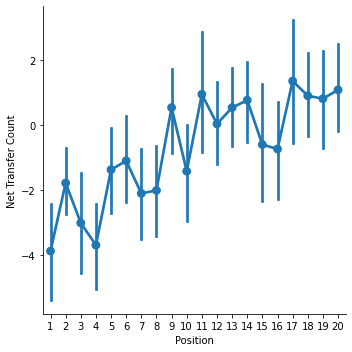

```python
sns.catplot(x= 'Position', y = "Net Transfer Count",data = df, kind = 'point')
```

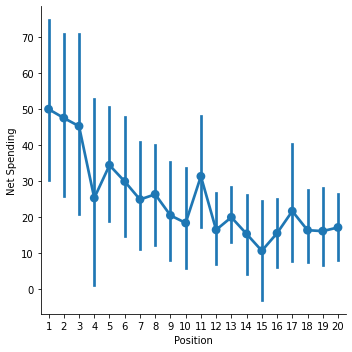

```python
sns.catplot(x= 'Position', y = "Net Spending",data = df, kind = 'point')
```

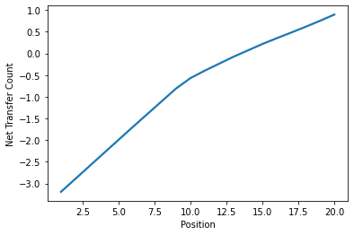

```python
sns.regplot(y = 'Net Transfer Count', x = 'Position',data = df, scatter = False,lowess =True)
```

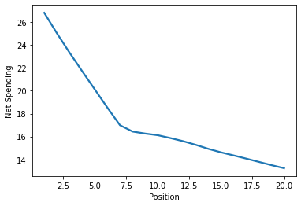

```python
sns.regplot(y = 'Net Spending', x = 'Position',data = df, scatter = False,lowess =True)
```

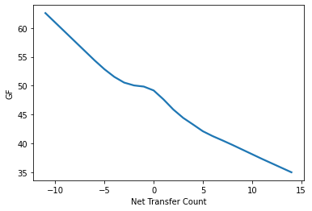

```python
sns.regplot(x = 'Net Transfer Count', y = 'GF',data = df, scatter = False,lowess =True)
```

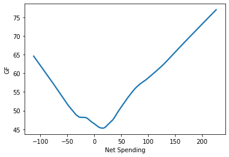

```python
sns.regplot(x = 'Net Spending', y = 'GF',data = df, scatter = False,lowess =True)
```

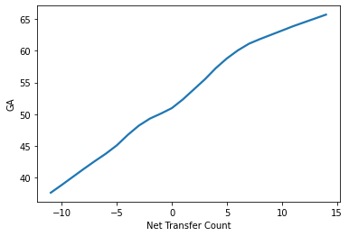

```python
sns.regplot(x = 'Net Transfer Count', y = 'GA',data = df, scatter = False,lowess =True)
```

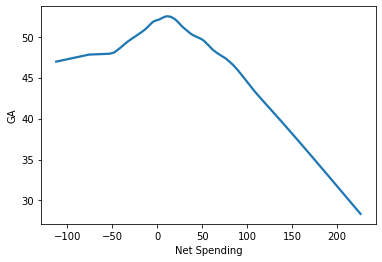

```python
sns.regplot(x = 'Net Spending', y = 'GA',data = df, scatter = False,lowess =True)
```

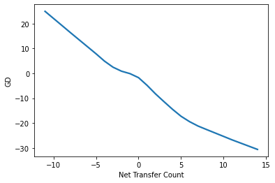

```python
sns.regplot(x = 'Net Transfer Count', y = 'GD',data = df, scatter = False,lowess =True)
```

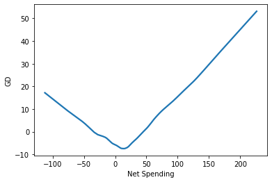

```python
sns.regplot(x = 'Net Spending', y = 'GD',data = df, scatter = False,lowess =True)
```

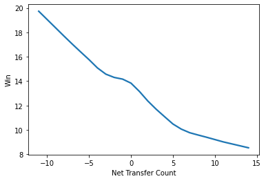

```python
sns.regplot(x = 'Net Transfer Count', y = 'Win',data = df, scatter = False,lowess =True)
```

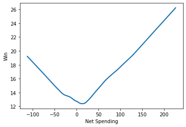

```python
sns.regplot(x = 'Net Spending', y = 'Win',data = df, scatter = False,lowess =True)
```

```python
from sklearn import linear_model
Y = df.Position
X = df.drop(columns = 'Points', axis = 1,inplace = True)
X = df.drop(columns = 'Qual_Reg', axis = 1,inplace = True)
X = df.drop(columns = 'Team', axis = 1)
X = X.drop(columns = 'Position', axis = 1)
```

```python
dt = tree.DecisionTreeRegressor(max_depth=6)
dt.fit(X,Y)
```

```
DecisionTreeRegressor(max_depth=6)
```

[figure not shown]

```python
import sklearn.tree as tree
from IPython.display import Image
import pydotplus

dt_feature_names = list(X.columns)
dt_target_names = np.array(Y.unique(),dtype=np.string_)
tree.export_graphviz(dt, out_file='tree.dot',
    feature_names=dt_feature_names, class_names=dt_target_names,
    filled=True)
graph = pydotplus.graph_from_dot_file('tree.dot')
Image(graph.create_png())
```

# Managerial Insights

Insight #1: Investing in home venue environments/ambience could be conducive to on-field success. Additionally filling stadiums to 45,000 will lead to more goals and satisifed fans, who are more likely to engage with the club further in the future.

Insight #2: Exploring ways to minimize the effects of winter could lead to more goals and more entertainment for fans/consumers. A potential solution is to change the season months, so there are less winter months in the season.

Insight #3: There are many different ways to become 1st place in the league, but important factors include gaining more than 79 points and winning more than 19 games. Once a team is able to achieve those stats, other factors stated in the ML decision tree will get you to a 1st place finish. Additionally selling more players than you buy and investing more money into your transfers while not gaining much money from transfers sold will contribute to a higher position.

This finding can be used as: Sell many of the low transfer valued players and bring in a few, but signifcantly higher valued players into the team could push your team to the top of the league. (Quanity vs Quality)

# Conclusion

Given more time and capability, there are a few additions that would’ve improved the findings. The first is to have incorporated a detailed weather dataset. The reason for this is that it will allow to drill down and determine if specific types of weather (not just winter/non-winter) affect the amount of goals in a game. It would’ve also helped to have a more in-depth attendance dataset. The dataset used only provided total attendance. This would be helpful for the venue insight if there was specific information on the breakdown between home and away fans in fan attendance.